# Native outliers for models

Lia Ossanna

2022-10-17

Analysis for Ossanna & Gornish (2022), “Efficacy of labile carbon addition to reduce fast-growing, invasive non-native plants: A review and meta-analysis”, *Journal of Applied Ecology*.

# Introduction

- This is the analysis to identify outliers in the single-moderator models, and relevant models generated through model selection.
  - See “Data cleaning and effect size” document for code for data cleaning and calculation of effect size (`code_data-cleaning.html`).

## Hat values and standardized residuals

- The first method for determining outliers is from Habeck 2015 (*AoB Plants*):
  - “In lieu of other options currently available within the package `metafor` when using the `rma.mv()` function, we define influential outliers as effect sizes with hat values (i.e. diagonal elements of the hat matrix) greater than two times the average hat value (i.e. influential) and standardized residual values exceeding 3.0 (i.e. outliers; Stevens 1984; Viechtbauer and Cheung 2010; Aguinis et al. 2013).”
- In other words, from Buchan 2019 (*Journal of Animal Ecology*), an observation is considered an outlier if it is “more than double the mean hat value of the dataset and standardized residuals greater than +/-3 as an influential outlier”.
- When plotted with the ratio of hat value to average hat value on the x-axis and the standardized residuals on the y-axis, horizontal lines can be added at +3 and -3, and a vertical line at 2. Outliers will fall in the top right or bottom right box.
  - Outliers are identified by adding labels to the points (`text(hat, rstn$resid, labels = nt$obs_ID, cex = 1, pos = 4)`), but this makes most of the plot unreadable, so this code is omitted. The paper and other relevant information for outliers are extracted.
- Code for this analysis was taken from Habeck 2015; Buchan 2019 used the same code.

## Studentized deleted residuals

- The second method is adapted from Viechtbauer 2010 (*Research Synthesis Methods*).
- Outliers are defined as having studentized deleted residuals outside the bounds of +/-1.96, but should not necessarily be deleted because of this basis alone; such cases “may call for closer inspection”, and “one could consider finding more than *k*/10 studentized deleted residuals larger than +/-1.96 in a set of *k* studies as unusual.”
  - However, this is computationally intensive. According to the `metafor` documentation, using the argument `reestimate = FALSE` in the `rstudent()` function approximates the residuals (“any variance/correlation components in the model are not re-estimated after deleting the *i*th case from the dataset”), and “often yields similar results”.
- Calculate DFBETAS values to identify the influence of removing the *i*th case; DFBETAS > +/-1 indicate influential cases.
  - Similarly, `reestimate = FALSE` can be applied to the `dftbas.rma.mv()` function to speed up analysis using estimation.
- Full analysis (not estimation) is not executed.
- Outliers and influential points are identified by their row number in the dataset (`nt`, or subset for model selection).
- Models are noted if outliers > *k*/10, and rows with the most extreme residuals.

## Code annotations

- See Biome section of “Non-native (exotic) outliers for models” document for annotated code (`code_nonnative-outliers.html`).

# Summary

## Habeck

- Models with Habeck outliers:
  - None

## Viechtbauer

- Models with Viechtbauer influential outliers:
  - C rate (categorical): 440
  - Model selection 14: 1697, 1002
- No models with more outliers than *k*/10.
- Models with influential points that are not outliers:
  - duration_first (categorical): 1615
  - C type: 346, 347
  - C rate (categorical): 452
  - Annual/perennial and grass/forb/shrub: 1618, 1628
  - Model selection 14: 1595

## Outlier set (fewer)

- Outliers removed:
  - Habeck outliers
  - Viechtbauer influential outliers
- Sets by model:
  - No moderators: none
  - Biome: none
  - Region: none
  - Soil suborder: none
  - duration_first (categorical): none
  - duration_last (categorical): none
  - C type: none
  - C rate (categorical): 440
  - C applications (categorical): none
  - Months applying C: none
  - Annual/perennial: none
  - Grass/forb/shrub: none
  - Annual/perennial and grass/forb/shrub: none
  - Plot size: none
  - Seeding of native: none
  - Model selection 14: 1697, 1002

# Setup

```r
library(tidyverse)
library(metafor)

# Load data ---------------------------------------------------------------

nt <- read.csv("data/cleaned/native-cleaned.csv") # data cleaning and effect size calculation in separate script
```

# No moderators (summary effect)

```r
nt.mv <- rma.mv(yi = yi,
                V = vi,
                random = ~ 1 | exp_ID / obs_ID,
                data = nt)
```

## Habeck method

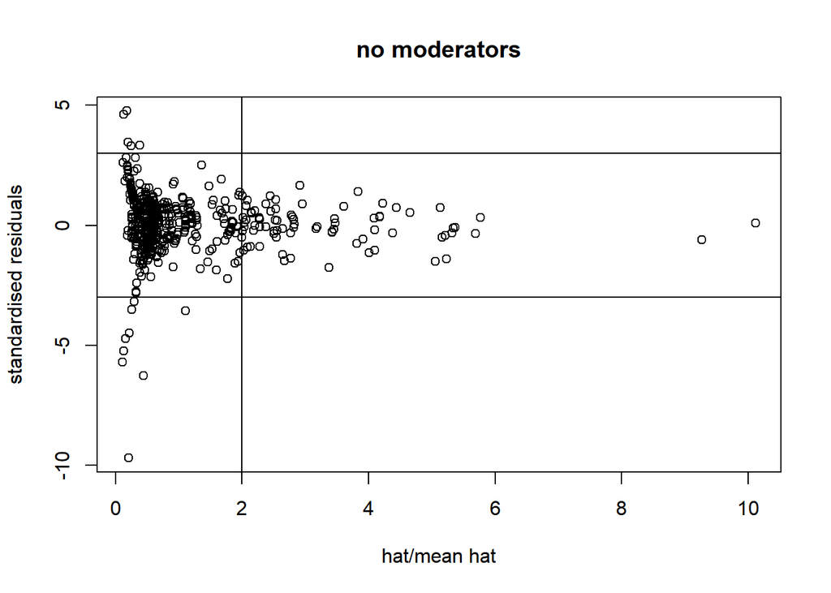

```r
rstn <- rstandard(nt.mv)
hat <- hatvalues(nt.mv) / mean(hatvalues(nt.mv))
plot(hat, rstn$resid,
     xlab = "hat/mean hat",
     ylab = "standardised residuals",
     main = "no moderators")
abline(h = -3)
abline(h = 3)
abline(v = 2)
```

## Viechtbauer method

Estimate

```r
rstd <- rstudent(nt.mv, reestimate = FALSE, progbar = TRUE) # ~ 26 min (Yoga)
```

```r
x <- subset(rstd, rstd$resid > 1.96)
y <- subset(rstd, rstd$resid < -1.96)
length(x[["resid"]]) + length(y[["resid"]])
```

```
## [1] 33
```

```r
nt.mv$k / 10
```

```
## [1] 65.5
```

```r
dfb <- dfbetas.rma.mv(nt.mv, reestimate = FALSE, progbar = TRUE) ## 23 min (Yoga)
```

```r
summary(dfb)
```

```
##     intrcpt
##  Min.   :-0.1663583
##  1st Qu.:-0.0085800
##  Median : 0.0001451
##  Mean   :-0.0005338
##  3rd Qu.: 0.0087457
##  Max.   : 0.1187857
```

# Biome

```r
nt.mv.bio <- rma.mv(yi = yi,
                    V = vi,
                    random = ~ 1 | exp_ID / obs_ID,
                    data = nt,
                    mods = ~ factor(biome) - 1)
```

## Habeck method

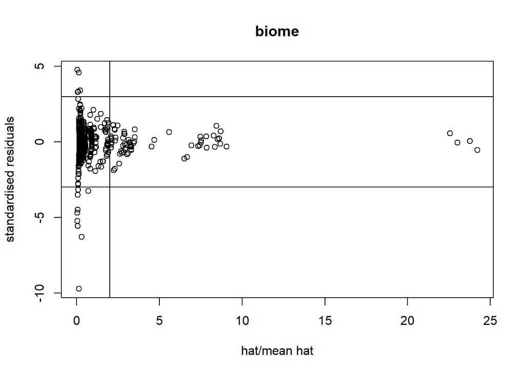

```r
rstn <- rstandard(nt.mv.bio)
hat <- hatvalues(nt.mv.bio) / mean(hatvalues(nt.mv.bio))
plot(hat, rstn$resid,
     xlab = "hat/mean hat",
     ylab = "standardised residuals",
     main = "biome")
abline(h = -3)
abline(h = 3)
abline(v = 2)
```

## Viechtbauer method

Estimate

```r
rstd.bio <- rstudent(nt.mv.bio, reestimate = FALSE, progbar = TRUE)
```

```r
x <- subset(rstd.bio, rstd.bio$resid > 1.96)
y <- subset(rstd.bio, rstd.bio$resid < -1.96)
length(x[["resid"]]) + length(y[["resid"]])
```

```
## [1] 30
```

```r
nt.mv.bio$k / 10
```

```
## [1] 65.5
```

```r
dfb.bio <- dfbetas.rma.mv(nt.mv.bio, reestimate = FALSE, progbar = TRUE)
```

```r
summary(dfb.bio)
```

```
##  factor.biome.coastal.grassland factor.biome.coastal.sandplain.grassland
##  Min.   :-0.3290269             Min.   :-0.902846
##  1st Qu.: 0.0000000             1st Qu.: 0.000000
##  Median : 0.0000000             Median : 0.000000
##  Mean   :-0.0003475             Mean   :-0.000094
##  3rd Qu.: 0.0000000             3rd Qu.: 0.000000
##  Max.   : 0.3493467             Max.   : 0.841289
##  factor.biome.cold.desert factor.biome.creosote.scrub
##  Min.   :-0.5513037       Min.   :-1.388e-01
##  1st Qu.: 0.0000000       1st Qu.: 0.000e+00
##  Median : 0.0000000       Median : 0.000e+00
##  Mean   : 0.0000914       Mean   : 7.130e-06
##  3rd Qu.: 0.0000000       3rd Qu.: 0.000e+00
##  Max.   : 0.7243420       Max.   : 1.435e-01
##  factor.biome.fescue.prairie factor.biome.grassy.woodland
##  Min.   :-0.2900802          Min.   :-0.2759294
##  1st Qu.: 0.0000000          1st Qu.: 0.0000000
##  Median : 0.0000000          Median : 0.0000000
##  Mean   :-0.0000414          Mean   :-0.0006872
##  3rd Qu.: 0.0000000          3rd Qu.: 0.0000000
##  Max.   : 0.3204814          Max.   : 0.2050464
##  factor.biome.mixed.grass.prairie factor.biome.Puget.lowland.prairie
##  Min.   :-0.5318624               Min.   :-1.961e-01
##  1st Qu.: 0.0000000               1st Qu.: 0.000e+00
##  Median : 0.0000000               Median : 0.000e+00
##  Mean   :-0.0008309               Mean   :-1.647e-05
##  3rd Qu.: 0.0000000               3rd Qu.: 0.000e+00
##  Max.   : 0.5126245               Max.   : 1.667e-01
##  factor.biome.sagebrush.steppe factor.biome.sedge.meadow
##  Min.   :-0.130054             Min.   :-9.941e-02
##  1st Qu.: 0.000000             1st Qu.: 0.000e+00
##  Median : 0.000000             Median : 0.000e+00
##  Mean   : 0.000161             Mean   : 1.020e-06
##  3rd Qu.: 0.000000             3rd Qu.: 0.000e+00
##  Max.   : 0.128075             Max.   : 6.440e-02
##  factor.biome.shortgrass.steppe factor.biome.tallgrass.prairie
##  Min.   :-1.591e-01             Min.   :-0.4789232
##  1st Qu.: 0.000e+00             1st Qu.: 0.0000000
##  Median : 0.000e+00             Median : 0.0000000
##  Mean   : 7.529e-05             Mean   :-0.0006396
##  3rd Qu.: 0.000e+00             3rd Qu.: 0.0000000
##  Max.   : 1.540e-01             Max.   : 0.2836294
##  factor.biome.upland.prairie factor.biome.wetland.prairie
##  Min.   :-0.3058329          Min.   :-1.577e-01
##  1st Qu.: 0.0000000          1st Qu.: 0.000e+00
##  Median : 0.0000000          Median : 0.000e+00
##  Mean   :-0.0000396          Mean   :-1.228e-05
##  3rd Qu.: 0.0000000          3rd Qu.: 0.000e+00
##  Max.   : 0.3755290          Max.   : 2.336e-01
```

# Region

```r
nt.mv.reg <- rma.mv(yi = yi,
                    V = vi,
                    random = ~ 1 | exp_ID / obs_ID,
                    data = nt,
                    mods = ~ factor(region) - 1)
```

## Habeck method

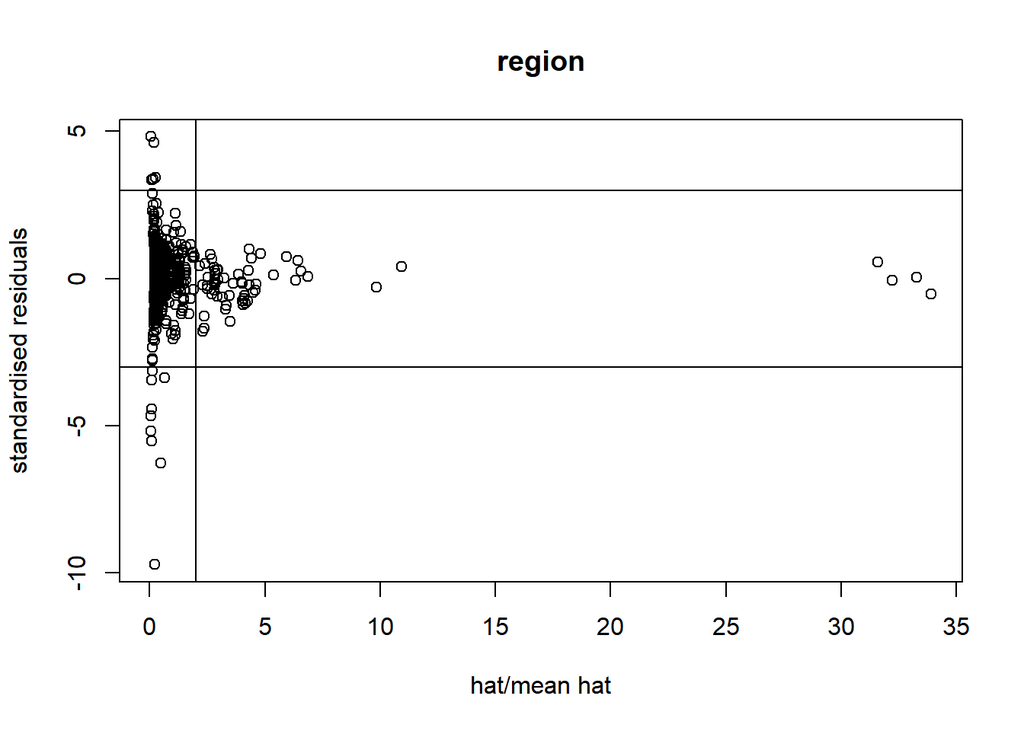

```r
rstn <- rstandard(nt.mv.reg)
hat <- hatvalues(nt.mv.reg) / mean(hatvalues(nt.mv.reg))
plot(hat, rstn$resid,
     xlab = "hat/mean hat",
     ylab = "standardised residuals",
     main = "region")
abline(h = -3)
abline(h = 3)
abline(v = 2)
```

## Viechtbauer method

Estimate

```r
rstd.reg <- rstudent(nt.mv.reg, reestimate = FALSE, progbar = TRUE) # ~ 11 min (ThinkCentre)
```

```r
x <- subset(rstd.reg, rstd.reg$resid > 1.96)
y <- subset(rstd.reg, rstd.reg$resid < -1.96)
length(x[["resid"]]) + length(y[["resid"]])
```

```
## [1] 30
```

```r
nt.mv.reg$k / 10
```

```
## [1] 65.5
```

```r
dfb.reg <- dfbetas.rma.mv(nt.mv.reg, reestimate = FALSE, progbar = TRUE) # ~ 11 min (ThinkCentre)
```

```r
summary(dfb.reg)
```

```
##  factor.region.central.Canada factor.region.coastal.CA..USA
##  Min.   :-0.1885872           Min.   :-0.316230
##  1st Qu.: 0.0000000           1st Qu.: 0.000000
##  Median : 0.0000000           Median : 0.000000
##  Mean   : 0.0008401           Mean   :-0.000294
##  3rd Qu.: 0.0000000           3rd Qu.: 0.000000
##  Max.   : 0.3291977           Max.   : 0.358146
##  factor.region.Great.Basin..USA factor.region.Great.Plains..USA
##  Min.   :-0.1522601             Min.   :-0.23180
##  1st Qu.: 0.0000000             1st Qu.: 0.00000
##  Median : 0.0000000             Median : 0.00000
##  Mean   : 0.0000086             Mean   :-0.00044
##  3rd Qu.: 0.0000000             3rd Qu.: 0.00000
##  Max.   : 0.1400172             Max.   : 0.14044
##  factor.region.Midwest..USA factor.region.northeast..USA
##  Min.   :-0.346984          Min.   :-0.8793858
##  1st Qu.: 0.000000          1st Qu.: 0.0000000
##  Median : 0.000000          Median : 0.0000000
##  Mean   :-0.000193          Mean   :-0.0000915
##  3rd Qu.: 0.000000          3rd Qu.: 0.0000000
##  Max.   : 0.240440          Max.   : 0.8194280
##  factor.region.Pacific.Northwest..USA factor.region.Rocky.Mountains..USA
##  Min.   :-0.2252523                   Min.   :-0.5132504
##  1st Qu.: 0.0000000                   1st Qu.: 0.0000000
##  Median : 0.0000000                   Median : 0.0000000
##  Mean   :-0.0005084                   Mean   :-0.0000422
##  3rd Qu.: 0.0000000                   3rd Qu.: 0.0000000
##  Max.   : 0.2338010                   Max.   : 0.4723561
##  factor.region.southeast.Australia factor.region.southwest..USA
##  Min.   :-0.2659562                Min.   :-1.302e-01
##  1st Qu.: 0.0000000                1st Qu.: 0.000e+00
##  Median : 0.0000000                Median : 0.000e+00
##  Mean   :-0.0006523                Mean   : 6.690e-06
##  3rd Qu.: 0.0000000                3rd Qu.: 0.000e+00
##  Max.   : 0.2243305                Max.   : 1.346e-01
```

# Soil suborder

```r
nt.mv.soil <- rma.mv(yi = yi,
                     V = vi,
                     random = ~ 1 | exp_ID / obs_ID,
                     data = nt,
                     mods = ~ factor(soil_suborder) - 1)
```

## Habeck method

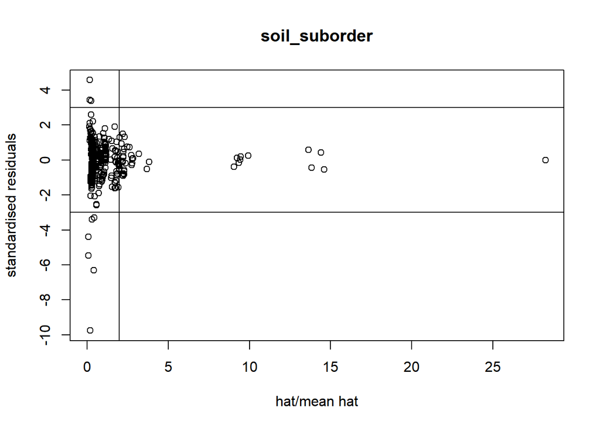

```r
rstn <- rstandard(nt.mv.soil)
hat <- hatvalues(nt.mv.soil) / mean(hatvalues(nt.mv.soil))
plot(hat, rstn$resid,
     xlab = "hat/mean hat",
     ylab = "standardised residuals",
     main = "soil_suborder")
abline(h = -3)
abline(h = 3)
abline(v = 2)
```

## Viechtbauer method

Estimate

```r
rstd.soil <- rstudent(nt.mv.soil, reestimate = FALSE, progbar = TRUE)
```

```r
x <- subset(rstd.soil, rstd.soil$resid > 1.96)
y <- subset(rstd.soil, rstd.soil$resid < -1.96)
length(x[["resid"]]) + length(y[["resid"]])
```

```
## [1] 17
```

```r
nt.mv.soil$k / 10
```

```
## [1] 48
```

```r
dfb.soil <- dfbetas.rma.mv(nt.mv.soil, reestimate = FALSE, progbar = TRUE)
```

```r
summary(dfb.soil)
```

```
##  factor.soil_suborder.Aqualfs factor.soil_suborder.Aquolls
##  Min.   :-0.1440427           Min.   :-0.6221009
##  1st Qu.: 0.0000000           1st Qu.: 0.0000000
##  Median : 0.0000000           Median : 0.0000000
##  Mean   :-0.0000146           Mean   :-0.0009674
##  3rd Qu.: 0.0000000           3rd Qu.: 0.0000000
##  Max.   : 0.2160958           Max.   : 0.4726207
##  NA's   :1                    NA's   :1
##  factor.soil_suborder.Argids factor.soil_suborder.Blacktown
##  Min.   :-0.335714           Min.   :-0.3699933
##  1st Qu.: 0.000000           1st Qu.: 0.0000000
##  Median : 0.000000           Median : 0.0000000
##  Mean   :-0.000701           Mean   :-0.0006848
##  3rd Qu.: 0.000000           3rd Qu.: 0.0000000
##  Max.   : 0.221956           Max.   : 0.3067329
##  NA's   :1                   NA's   :1
##  factor.soil_suborder.Cambids factor.soil_suborder.Chernozems
##  Min.   :-0.2480071           Min.   :-0.204865
##  1st Qu.: 0.0000000           1st Qu.: 0.000000
##  Median : 0.0000000           Median : 0.000000
##  Mean   : 0.0000714           Mean   : 0.001137
##  3rd Qu.: 0.0000000           3rd Qu.: 0.000000
##  Max.   : 0.2259226           Max.   : 0.332097
##  NA's   :1                    NA's   :1
##  factor.soil_suborder.Durids factor.soil_suborder.Humults
##  Min.   :-0.1786377          Min.   :-0.4104872
##  1st Qu.: 0.0000000          1st Qu.: 0.0000000
##  Median : 0.0000000          Median : 0.0000000
##  Mean   : 0.0000355          Mean   : 0.0000169
##  3rd Qu.: 0.0000000          3rd Qu.: 0.0000000
##  Max.   : 0.1803965          Max.   : 0.5314303
##  NA's   :1                   NA's   :1
##  factor.soil_suborder.Psamments..Udepts factor.soil_suborder.Udolls
##  Min.   :-0.8796343                     Min.   :-0.4853590
##  1st Qu.: 0.0000000                     1st Qu.: 0.0000000
##  Median : 0.0000000                     Median : 0.0000000
##  Mean   :-0.0001224                     Mean   : 0.0000229
##  3rd Qu.: 0.0000000                     3rd Qu.: 0.0000000
##  Max.   : 0.8210021                     Max.   : 0.3298631
##  NA's   :1                              NA's   :1
```

[output cut: 17 more lines]

```
##  Min.   :-0.1665997           Min.   :-0.363004
##  1st Qu.: 0.0000000           1st Qu.: 0.000000
##  Median : 0.0000000           Median : 0.000000
##  Mean   :-0.0001205           Mean   : 0.000094
##  3rd Qu.: 0.0000000           3rd Qu.: 0.000000
##  Max.   : 0.1639029           Max.   : 0.271731
##  NA's   :1                    NA's   :1
##  factor.soil_suborder.Xerolls
##  Min.   :-0.3399347
##  1st Qu.: 0.0000000
##  Median : 0.0000000
##  Mean   :-0.0001072
##  3rd Qu.: 0.0000000
##  Max.   : 0.1315843
##  NA's   :1
```

# duration_first (categorical)

```r
nt.mv.dfc <- rma.mv(yi = yi,
                    V = vi,
                    random = ~ 1 | exp_ID / obs_ID,
                    data = nt,
                    mods = ~ factor(dfc) - 1)
```

## Habeck method

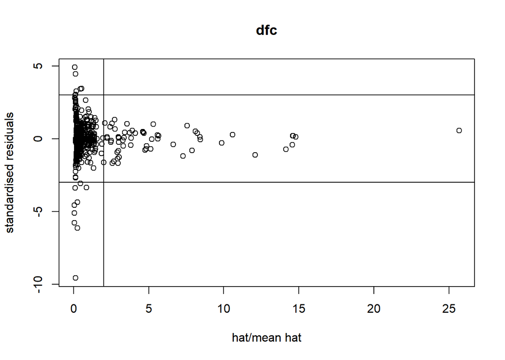

```r
rstn <- rstandard(nt.mv.dfc)
hat <- hatvalues(nt.mv.dfc) / mean(hatvalues(nt.mv.dfc))
plot(hat, rstn$resid,
     xlab = "hat/mean hat",
     ylab = "standardised residuals",
     main = "dfc")
abline(h = -3)
abline(h = 3)
abline(v = 2)
```

## Viechtbauer method

Estimate

```r
rstd.dfc <- rstudent(nt.mv.dfc, reestimate = FALSE, progbar = TRUE)
```

```r
x <- subset(rstd.dfc, rstd.dfc$resid > 1.96)
y <- subset(rstd.dfc, rstd.dfc$resid < -1.96)
length(x[["resid"]]) + length(y[["resid"]])
```

```
## [1] 36
```

```r
nt.mv.dfc$k / 10
```

```
## [1] 65.5
```

```r
dfb.dfc <- dfbetas.rma.mv(nt.mv.dfc, reestimate = FALSE, progbar = TRUE)
```

```r
summary(dfb.dfc)
```

```
##   factor.dfc.3        factor.dfc.5.6       factor.dfc.7.12
##  Min.   :-0.4997226   Min.   :-0.5831052   Min.   :-0.3428319
##  1st Qu.: 0.0000000   1st Qu.: 0.0000000   1st Qu.: 0.0000000
##  Median : 0.0000000   Median : 0.0000000   Median : 0.0000000
##  Mean   :-0.0001785   Mean   : 0.0005598   Mean   : 0.0002244
##  3rd Qu.: 0.0000000   3rd Qu.: 0.0000000   3rd Qu.: 0.0000000
##  Max.   : 0.2238507   Max.   : 1.0452635   Max.   : 0.2448025
##  factor.dfc.12.18    factor.dfc.19.24     factor.dfc.25.36
##  Min.   :-0.252885   Min.   :-0.3306051   Min.   :-0.3638553
##  1st Qu.:-0.001269   1st Qu.: 0.0000000   1st Qu.:-0.0004502
##  Median : 0.000000   Median : 0.0000000   Median : 0.0000000
##  Mean   :-0.001285   Mean   : 0.0005073   Mean   :-0.0003710
##  3rd Qu.: 0.001293   3rd Qu.: 0.0000000   3rd Qu.: 0.0004819
##  Max.   : 0.412148   Max.   : 0.2641405   Max.   : 0.2939146
##  factor.dfc.37.50     factor.dfc.100.200   factor.dfc..200
##  Min.   :-0.0977258   Min.   :-0.3181273   Min.   :-0.181202
##  1st Qu.:-0.0010387   1st Qu.: 0.0000000   1st Qu.:-0.001268
##  Median : 0.0000000   Median : 0.0000000   Median : 0.000000
##  Mean   : 0.0005104   Mean   : 0.0000049   Mean   :-0.000721
##  3rd Qu.: 0.0007931   3rd Qu.: 0.0000000   3rd Qu.: 0.001269
##  Max.   : 0.1226347   Max.   : 0.2512262   Max.   : 0.186096
```

```r
subset(dfb.dfc, dfb.dfc$factor.dfc.5.6 > 1) # 651
```

```
##     factor.dfc.3 factor.dfc.5.6 factor.dfc.7.12 factor.dfc.12.18
## 651            0       1.045264       0.1577416                0
##     factor.dfc.19.24 factor.dfc.25.36 factor.dfc.37.50 factor.dfc.100.200
## 651      0.008620171                0                0                  0
##     factor.dfc..200
## 651               0
```

```r
x$slab # not influential
```

```
##  [1]   7   9  15  26  27  28  38  39  50  53  58 212 225 228 300 303 306 508 527
## [20] 576 590
```

```r
nt[651, c("paper", "obs_ID", "dfc")]
```

```
##
##                  paper obs_ID dfc
## 651 Reever Morgan_1999   1615 5-6
```

- Observation 1615 is influential, but not an outlier.

# duration_last (categorical)

```r
nt.mv.dlc <- rma.mv(yi = yi,
                    V = vi,
                    random = ~ 1 | exp_ID / obs_ID,
                    data = nt,
                    mods = ~ factor(dlc) - 1)
```

## Habeck method

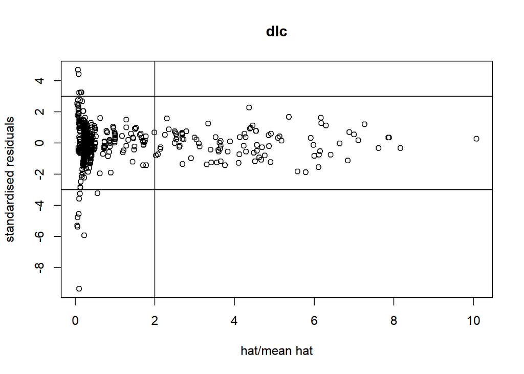

```r
rstn <- rstandard(nt.mv.dlc)
hat <- hatvalues(nt.mv.dlc) / mean(hatvalues(nt.mv.dlc))
plot(hat, rstn$resid,
     xlab = "hat/mean hat",
     ylab = "standardised residuals",
     main = "dlc")
abline(h = -3)
abline(h = 3)
abline(v = 2)
```

## Viechtbauer method

Estimate

```r
rstd.dlc <- rstudent(nt.mv.dlc, reestimate = FALSE, progbar = TRUE)
```

```r
x <- subset(rstd.dlc, rstd.dlc$resid > 1.96)
y <- subset(rstd.dlc, rstd.dlc$resid < -1.96)
length(x[["resid"]]) + length(y[["resid"]])
```

```
## [1] 34
```

```r
nt.mv.dlc$k / 10
```

```
## [1] 65.5
```

```r
dfb.dlc <- dfbetas.rma.mv(nt.mv.dlc, reestimate = FALSE, progbar = TRUE)
```

```r
summary(dfb.dlc)
```

```
##  factor.dlc.0.1.5      factor.dlc.2        factor.dlc.3.3.5
##  Min.   :-3.158e-01   Min.   :-0.2440387   Min.   :-0.6348640
##  1st Qu.:-1.778e-05   1st Qu.:-0.0001677   1st Qu.:-0.0005090
##  Median : 0.000e+00   Median : 0.0000000   Median : 0.0000000
##  Mean   :-7.098e-04   Mean   :-0.0002344   Mean   :-0.0000626
##  3rd Qu.: 1.421e-05   3rd Qu.: 0.0001969   3rd Qu.: 0.0005814
##  Max.   : 3.116e-01   Max.   : 0.2561712   Max.   : 0.7268669
##  factor.dlc.4.6       factor.dlc.7.12      factor.dlc.13.18
##  Min.   :-0.3351839   Min.   :-0.3935398   Min.   :-0.1996630
##  1st Qu.:-0.0003408   1st Qu.:-0.0004865   1st Qu.:-0.0019441
##  Median : 0.0000000   Median : 0.0000000   Median : 0.0000000
##  Mean   :-0.0018466   Mean   : 0.0005097   Mean   : 0.0002192
##  3rd Qu.: 0.0003550   3rd Qu.: 0.0006510   3rd Qu.: 0.0023012
##  Max.   : 0.2413249   Max.   : 0.4483961   Max.   : 0.2588568
##  factor.dlc.19.24     factor.dlc.36.49     factor.dlc..100
##  Min.   :-0.4022864   Min.   :-0.2103659   Min.   :-0.486590
##  1st Qu.: 0.0000000   1st Qu.: 0.0000000   1st Qu.: 0.000000
##  Median : 0.0000000   Median : 0.0000000   Median : 0.000000
##  Mean   : 0.0006152   Mean   : 0.0001542   Mean   : 0.000182
##  3rd Qu.: 0.0000000   3rd Qu.: 0.0000000   3rd Qu.: 0.000000
##  Max.   : 0.3015142   Max.   : 0.1857828   Max.   : 0.428760
```

# C type

```r
nt.mv.ctyp <- rma.mv(yi = yi,
                     V = vi,
                     random = ~ 1 | exp_ID / obs_ID,
                     data = nt,
                     mods = ~ factor(C_type) - 1)
```

## Habeck method

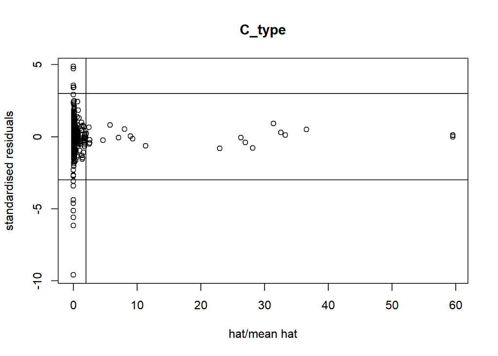

```r
rstn <- rstandard(nt.mv.ctyp)
hat <- hatvalues(nt.mv.ctyp) / mean(hatvalues(nt.mv.ctyp))
plot(hat, rstn$resid,
     xlab = "hat/mean hat",
     ylab = "standardised residuals",
     main = "C_type")
abline(h = -3)
abline(h = 3)
abline(v = 2)
```

## Viechtbauer method

Estimate

```r
rstd.ctyp <- rstudent(nt.mv.ctyp, reestimate = FALSE, progbar = TRUE)
```

```r
x <- subset(rstd.ctyp, rstd.ctyp$resid > 1.96)
y <- subset(rstd.ctyp, rstd.ctyp$resid < -1.96)
length(x[["resid"]]) + length(y[["resid"]])
```

```
## [1] 27
```

```r
nt.mv.ctyp$k / 10
```

```
## [1] 65.5
```

```r
dfb.ctyp <- dfbetas.rma.mv(nt.mv.ctyp, reestimate = FALSE, progbar = TRUE)
```

```r
summary(dfb.ctyp)
```

```
##  factor.C_type.dextrose factor.C_type.lignin factor.C_type.lignin.AND.sucrose
##  Min.   :-0.5988492     Min.   :-1.7486977   Min.   :-0.0695700
##  1st Qu.: 0.0000000     1st Qu.:-0.0004526   1st Qu.:-0.0003331
##  Median : 0.0000000     Median :-0.0000034   Median :-0.0000023
##  Mean   : 0.0005433     Mean   : 0.0000379   Mean   :-0.0002003
##  3rd Qu.: 0.0000000     3rd Qu.: 0.0004753   3rd Qu.: 0.0003496
##  Max.   : 0.9531095     Max.   : 1.9500444   Max.   : 0.0279272
##  NA's   :3              NA's   :3            NA's   :3
##  factor.C_type.mulch  factor.C_type.sawdust factor.C_type.sawdust.AND.woodchip
##  Min.   :-0.7019508   Min.   :-0.2910693    Min.   :-0.0985133
##  1st Qu.:-0.0003372   1st Qu.:-0.0001946    1st Qu.:-0.0000023
##  Median : 0.0000000   Median :-0.0000011    Median : 0.0000000
##  Mean   : 0.0002794   Mean   :-0.0000326    Mean   :-0.0001628
##  3rd Qu.: 0.0003511   3rd Qu.: 0.0001968    3rd Qu.: 0.0000023
##  Max.   : 0.8466616   Max.   : 0.2814678    Max.   : 0.0033057
##  NA's   :3            NA's   :3             NA's   :3
##  factor.C_type.straw  factor.C_type.sucrose factor.C_type.sucrose.AND.mulch
##  Min.   :-0.6720489   Min.   :-0.2064739    Min.   :-0.1408222
##  1st Qu.:-0.0001301   1st Qu.:-0.0114202    1st Qu.:-0.0002401
##  Median : 0.0000000   Median :-0.0000005    Median : 0.0000000
##  Mean   :-0.0003337   Mean   :-0.0006063    Mean   : 0.0000411
##  3rd Qu.: 0.0001340   3rd Qu.: 0.0113057    3rd Qu.: 0.0002507
##  Max.   : 0.3457329   Max.   : 0.1244601    Max.   : 0.1283856
##  NA's   :3            NA's   :3             NA's   :3
##  factor.C_type.sucrose.AND.sawdust factor.C_type.woodchip
##  Min.   :-0.2535103                Min.   :-0.0762136
##  1st Qu.:-0.0001366                1st Qu.:-0.0000029
##  Median :-0.0000009                Median : 0.0000000
##  Mean   :-0.0006790                Mean   :-0.0000762
##  3rd Qu.: 0.0001518                3rd Qu.: 0.0000029
##  Max.   : 0.1616483                Max.   : 0.0683264
##  NA's   :3                         NA's   :3
```

```r
subset(dfb.ctyp, dfb.ctyp$factor.C_type.lignin > 1) # 230
```

```
##     factor.C_type.dextrose factor.C_type.lignin
## 230                      0             1.950044
##     factor.C_type.lignin.AND.sucrose factor.C_type.mulch factor.C_type.sawdust
## 230                                0                   0         -1.666724e-16
##     factor.C_type.sawdust.AND.woodchip factor.C_type.straw
## 230                                  0                   0
##     factor.C_type.sucrose factor.C_type.sucrose.AND.mulch
## 230         -4.880108e-16                               0
##     factor.C_type.sucrose.AND.sawdust factor.C_type.woodchip
## 230                     -1.483062e-15                      0
```

```r
x$slab # not influential
```

```
##  [1]   7  26  28  38  39 212 225 300 303 306 508 527 576 590
```

```r
subset(dfb.ctyp, dfb.ctyp$factor.C_type.lignin < -1) # 229
```

```
##     factor.C_type.dextrose factor.C_type.lignin
## 229                      0            -1.748698
##     factor.C_type.lignin.AND.sucrose factor.C_type.mulch factor.C_type.sawdust
## 229                                0                   0         -7.576018e-17
##     factor.C_type.sawdust.AND.woodchip factor.C_type.straw
## 229                                  0                   0
##     factor.C_type.sucrose factor.C_type.sucrose.AND.mulch
## 229         -9.760216e-16                               0
##     factor.C_type.sucrose.AND.sawdust factor.C_type.woodchip
## 229                     -1.483062e-15                      0
```

```r
y$slab # not influential
```

```
##  [1] 192 310 313 451 456 471 478 479 484 497 521 531 617
```

```r
nt[c(230, 229), c("paper", "obs_ID", "C_type")]
```

```
##
##          paper obs_ID C_type
## 230 Burke_2013    347 lignin
## 229 Burke_2013    346 lignin
```

- Observations 346 and 347 are influential, but not outliers.

# C rate (categorical)

```r
nt.mv.cratc <- rma.mv(yi = yi,
                     V = vi,
                     random = ~ 1 | exp_ID / obs_ID,
                     data = nt,
                     mods = ~ factor(cratc) - 1)
```

## Habeck method

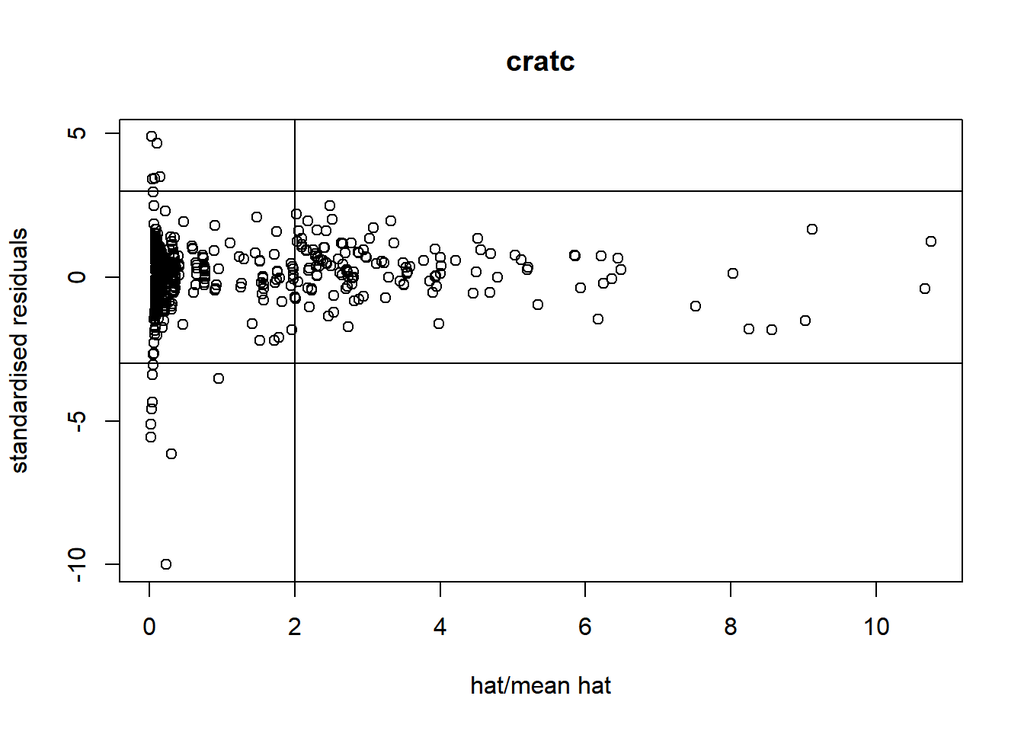

```r
rstn <- rstandard(nt.mv.cratc)
hat <- hatvalues(nt.mv.cratc) / mean(hatvalues(nt.mv.cratc))
plot(hat, rstn$resid,
     xlab = "hat/mean hat",
     ylab = "standardised residuals",
     main = "cratc")
abline(h = -3)
abline(h = 3)
abline(v = 2)
```

## Viechtbauer method

Estimate

```r
rstd.cratc <- rstudent(nt.mv.cratc, reestimate = FALSE, progbar = TRUE)
```

```r
x <- subset(rstd.cratc, rstd.cratc$resid > 1.96)
y <- subset(rstd.cratc, rstd.cratc$resid < -1.96)
length(x[["resid"]]) + length(y[["resid"]])
```

```
## [1] 34
```

```r
nt.mv.cratc$k / 10
```

```
## [1] 64
```

```r
dfb.cratc <- dfbetas.rma.mv(nt.mv.cratc, reestimate = FALSE, progbar = TRUE)
```

```r
summary(dfb.cratc)
```

```
##  factor.cratc.30.100  factor.cratc.133.160 factor.cratc.174.200
##  Min.   :-0.3854682   Min.   :-1.899e-01   Min.   :-0.8297142
##  1st Qu.:-0.0007600   1st Qu.:-7.979e-03   1st Qu.:-0.0000470
##  Median :-0.0000788   Median :-7.755e-05   Median :-0.0000048
##  Mean   :-0.0004537   Mean   :-7.043e-04   Mean   :-0.0011461
##  3rd Qu.: 0.0006829   3rd Qu.: 7.122e-03   3rd Qu.: 0.0000434
##  Max.   : 0.3769279   Max.   : 9.119e-02   Max.   : 0.1185996
##  factor.cratc.210.300 factor.cratc.330.400 factor.cratc.420.500
##  Min.   :-2.593e-01   Min.   :-0.3956048   Min.   :-0.4904393
##  1st Qu.:-8.378e-04   1st Qu.:-0.0007273   1st Qu.:-0.0002562
##  Median :-7.512e-05   Median :-0.0000483   Median :-0.0000110
##  Mean   :-5.155e-04   Mean   :-0.0010154   Mean   :-0.0008676
##  3rd Qu.: 7.948e-04   3rd Qu.: 0.0007492   3rd Qu.: 0.0002832
##  Max.   : 3.158e-01   Max.   : 0.1781597   Max.   : 0.3925272
##  factor.cratc.506.600 factor.cratc.620.700 factor.cratc.714.999
##  Min.   :-0.3777152   Min.   :-0.2659009   Min.   :-0.5636623
##  1st Qu.:-0.0005538   1st Qu.:-0.0005767   1st Qu.:-0.0006403
##  Median :-0.0000332   Median :-0.0000346   Median :-0.0000339
##  Mean   :-0.0013351   Mean   :-0.0001987   Mean   :-0.0002890
##  3rd Qu.: 0.0005740   3rd Qu.: 0.0006357   3rd Qu.: 0.0006983
##  Max.   : 0.4630009   Max.   : 0.3333481   Max.   : 0.4324593
##  factor.cratc.1000.1330 factor.cratc.1600.2000 factor.cratc.2110.3000
##  Min.   :-0.4459749     Min.   :-0.7810767     Min.   :-3.050e-01
##  1st Qu.:-0.0013424     1st Qu.:-0.0009674     1st Qu.:-1.309e-03
##  Median :-0.0000707     Median : 0.0000048     Median :-2.867e-05
##  Mean   : 0.0000069     Mean   : 0.0005019     Mean   : 8.069e-04
##  3rd Qu.: 0.0014717     3rd Qu.: 0.0011610     3rd Qu.: 1.521e-03
##  Max.   : 0.3006488     Max.   : 0.4703815     Max.   : 2.813e-01
##  factor.cratc.3346.5000 factor.cratc..5000
##  Min.   :-0.3814817     Min.   :-0.9076422
##  1st Qu.:-0.0009468     1st Qu.:-0.0003360
##  Median :-0.0000195     Median :-0.0000011
##  Mean   : 0.0007165     Mean   : 0.0011221
##  3rd Qu.: 0.0011008     3rd Qu.: 0.0003965
##  Max.   : 0.4015752     Max.   : 1.4575262
```

```r
subset(dfb.cratc, dfb.cratc$factor.cratc..5000 > 1) # 247, 253
```

```
##     factor.cratc.30.100 factor.cratc.133.160 factor.cratc.174.200
## 247        -0.001419134        -0.0008800543        -8.598024e-05
## 253         0.002124106         0.0013172320         1.286920e-04
##     factor.cratc.210.300 factor.cratc.330.400 factor.cratc.420.500
## 247         -0.001746349         -0.001582071        -0.0005884112
## 253          0.002613870          0.002367984         0.0008807117
##     factor.cratc.506.600 factor.cratc.620.700 factor.cratc.714.999
## 247         -0.001212007         -0.001715450         -0.001382461
## 253          0.001814086          0.002567621          0.002069216
##     factor.cratc.1000.1330 factor.cratc.1600.2000 factor.cratc.2110.3000
## 247           -0.003058219           -0.001005511           -0.003011924
## 253            0.004577426            0.001505011            0.004508135
##     factor.cratc.3346.5000 factor.cratc..5000
## 247            -0.02321429           1.330539
## 253             0.03474628           1.457526
```

```r
x$slab # 247
```

```
##  [1]   7   9  15  26  28  38 212 247 300 303 306 508 527 576 590
```

```r
nt[c(247, 253), c("paper", "obs_ID", "cratc")]
```

```
##
##         paper obs_ID cratc
## 247 Gray_2013    440 >5000
## 253 Gray_2013    452 >5000
```

- Observation 440 is an influential outlier.
- Observation 452 is influential, but not an outlier.

# C applications total (categorical)

```r
nt.mv.capc <- rma.mv(yi = yi,
                     V = vi,
                     random = ~ 1 | exp_ID / obs_ID,
                     data = nt,
                     mods = ~ factor(capc) - 1)
```

## Habeck method

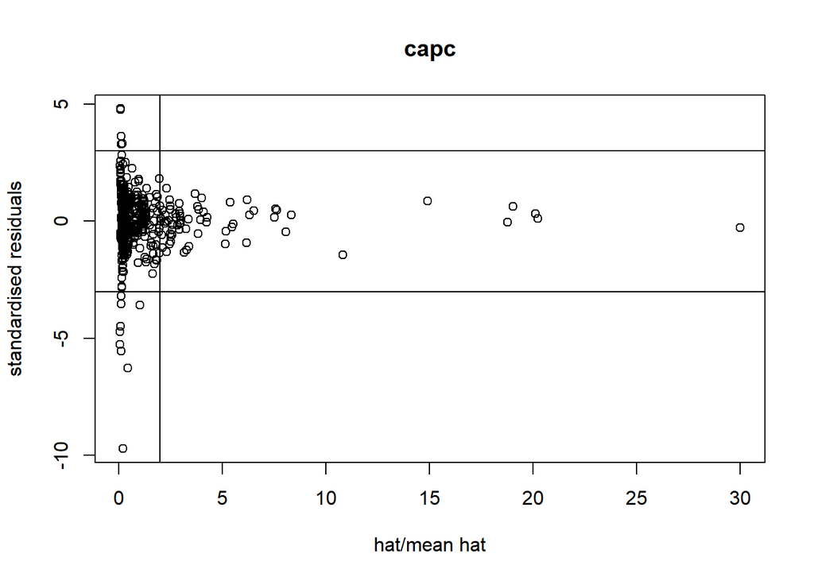

```r
rstn <- rstandard(nt.mv.capc)
hat <- hatvalues(nt.mv.capc) / mean(hatvalues(nt.mv.capc))
plot(hat, rstn$resid,
     xlab = "hat/mean hat",
     ylab = "standardised residuals",
     main = "capc")
abline(h = -3)
abline(h = 3)
abline(v = 2)
```

## Viechtbauer method

Estimate

```r
rstd.capc <- rstudent(nt.mv.capc, reestimate = FALSE, progbar = TRUE)
```

```r
x <- subset(rstd.capc, rstd.capc$resid > 1.96)
y <- subset(rstd.capc, rstd.capc$resid < -1.96)
length(x[["resid"]]) + length(y[["resid"]])
```

```
## [1] 31
```

```r
nt.mv.capc$k / 10
```

```
## [1] 65.5
```

```r
dfb.capc <- dfbetas.rma.mv(nt.mv.capc, reestimate = FALSE, progbar = TRUE)
```

```r
summary(dfb.capc)
```

```
##  factor.capc.1        factor.capc.2        factor.capc.3.6
##  Min.   :-0.3002301   Min.   :-0.2108599   Min.   :-0.2766120
##  1st Qu.:-0.0018584   1st Qu.:-0.0017577   1st Qu.:-0.0009768
##  Median : 0.0000000   Median : 0.0000000   Median : 0.0000000
##  Mean   :-0.0003644   Mean   :-0.0001226   Mean   :-0.0000285
##  3rd Qu.: 0.0023824   3rd Qu.: 0.0015772   3rd Qu.: 0.0008771
##  Max.   : 0.2089422   Max.   : 0.2023796   Max.   : 0.3836819
##  factor.capc.7.10     factor.capc.15.22    factor.capc.32.40
##  Min.   :-0.3282201   Min.   :-0.7713397   Min.   :-0.2326537
##  1st Qu.:-0.0000723   1st Qu.: 0.0000000   1st Qu.:-0.0000846
##  Median : 0.0000000   Median : 0.0000000   Median : 0.0000000
##  Mean   :-0.0006934   Mean   :-0.0002615   Mean   :-0.0002502
##  3rd Qu.: 0.0000587   3rd Qu.: 0.0000000   3rd Qu.: 0.0000668
##  Max.   : 0.1848462   Max.   : 0.7619833   Max.   : 0.3243138
##  factor.capc..40
##  Min.   :-2.145e-01
##  1st Qu.:-1.106e-05
##  Median : 0.000e+00
##  Mean   : 2.880e-05
##  3rd Qu.: 8.860e-06
##  Max.   : 2.368e-01
```

# Months applying C

```r
nt.mv.capt <- rma.mv(yi = yi,
                     V = vi,
                     random = ~ 1 | exp_ID / obs_ID,
                     data = nt,
                     mods = ~ factor(capt) - 1)
```

## Habeck method

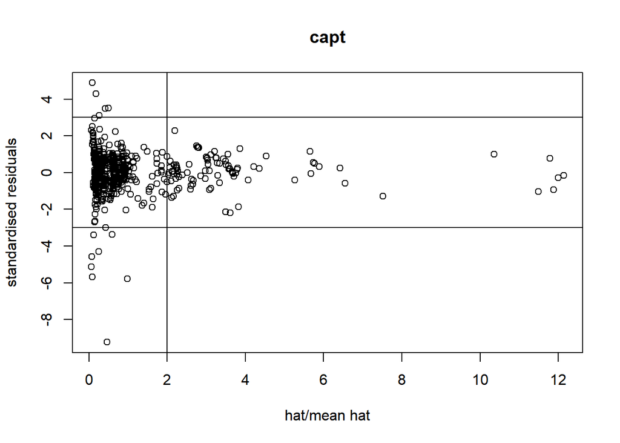

```r
rstn <- rstandard(nt.mv.capt)
hat <- hatvalues(nt.mv.capt) / mean(hatvalues(nt.mv.capt))
plot(hat, rstn$resid,
     xlab = "hat/mean hat",
     ylab = "standardised residuals",
     main = "capt")
abline(h = -3)
abline(h = 3)
abline(v = 2)
```

## Viechtbauer method

Estimate

```r
rstd.capt <- rstudent(nt.mv.capt, reestimate = FALSE, progbar = TRUE)
```

```r
x <- subset(rstd.capt, rstd.capt$resid > 1.96)
y <- subset(rstd.capt, rstd.capt$resid < -1.96)
length(x[["resid"]]) + length(y[["resid"]])
```

```
## [1] 32
```

```r
nt.mv.capt$k / 10
```

```
## [1] 65.5
```

```r
dfb.capt <- dfbetas.rma.mv(nt.mv.capt, reestimate = FALSE, progbar = TRUE)
```

```r
summary(dfb.capt)
```

```
##  factor.capt.1.application.total factor.capt.1.6      factor.capt.7.12
##  Min.   :-0.2584460              Min.   :-0.2349860   Min.   :-0.4839953
##  1st Qu.:-0.0010249              1st Qu.:-0.0014304   1st Qu.:-0.0010928
##  Median : 0.0000000              Median : 0.0000000   Median : 0.0000000
##  Mean   : 0.0002101              Mean   :-0.0006971   Mean   : 0.0002859
##  3rd Qu.: 0.0013312              3rd Qu.: 0.0015401   3rd Qu.: 0.0011857
##  Max.   : 0.2067157              Max.   : 0.2401688   Max.   : 0.4120329
##  factor.capt.13.24   factor.capt.25.36    factor.capt.37.48
##  Min.   :-0.216460   Min.   :-0.5835726   Min.   :-0.1083535
##  1st Qu.:-0.001337   1st Qu.: 0.0000000   1st Qu.:-0.0003701
##  Median : 0.000000   Median : 0.0000000   Median : 0.0000000
##  Mean   :-0.000510   Mean   :-0.0005076   Mean   : 0.0002944
##  3rd Qu.: 0.001647   3rd Qu.: 0.0000000   3rd Qu.: 0.0002489
##  Max.   : 0.287014   Max.   : 0.6713504   Max.   : 0.1717228
##  factor.capt..48
##  Min.   :-0.3956535
##  1st Qu.:-0.0006242
##  Median : 0.0000000
##  Mean   :-0.0007624
##  3rd Qu.: 0.0004017
##  Max.   : 0.3871812
```

# Annual/perennial

```r
nt.mv.panp <- rma.mv(yi = yi,
                     V = vi,
                     random = ~ 1 | exp_ID / obs_ID,
                     data = nt,
                     mods = ~ factor(plant_anper) - 1)
```

## Habeck method

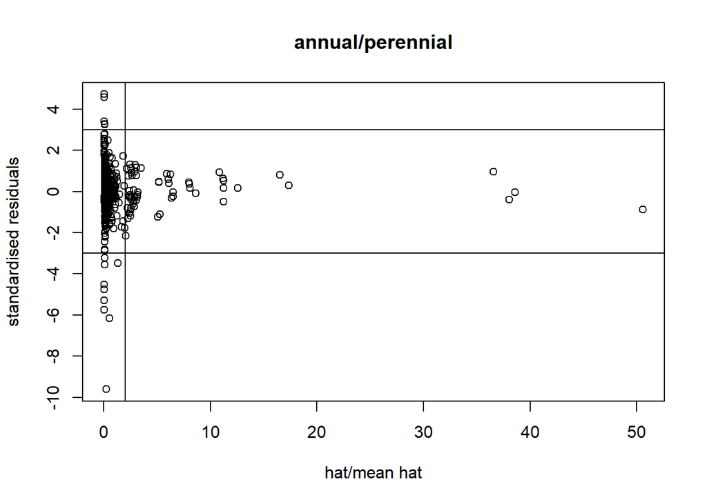

```r
rstn <- rstandard(nt.mv.panp)
hat <- hatvalues(nt.mv.panp) / mean(hatvalues(nt.mv.panp))
plot(hat, rstn$resid,
     xlab = "hat/mean hat",
     ylab = "standardised residuals",
     main = "annual/perennial")
abline(h = -3)
abline(h = 3)
abline(v = 2)
```

## Viechtbauer method

Estimate

```r
rstd.panp <- rstudent(nt.mv.panp, reestimate = FALSE, progbar = TRUE)
```

```r
x <- subset(rstd.panp, rstd.panp$resid > 1.96)
y <- subset(rstd.panp, rstd.panp$resid < -1.96)
length(x[["resid"]]) + length(y[["resid"]])
```

```
## [1] 31
```

```r
nt.mv.panp$k / 10
```

```
## [1] 65.5
```

```r
dfb.panp <- dfbetas.rma.mv(nt.mv.panp, reestimate = FALSE, progbar = TRUE)
```

```r
summary(dfb.panp)
```

```
##  factor.plant_anper.annual factor.plant_anper.biennial
##  Min.   :-0.2371834        Min.   :-0.7659596
##  1st Qu.:-0.0048758        1st Qu.:-0.0012080
##  Median : 0.0001284        Median : 0.0001504
##  Mean   : 0.0000054        Mean   : 0.0001625
##  3rd Qu.: 0.0043729        3rd Qu.: 0.0013894
##  Max.   : 0.4499370        Max.   : 0.8035069
##  factor.plant_anper.perennial factor.plant_anper.unknown
##  Min.   :-0.1803191           Min.   :-0.2924206
##  1st Qu.:-0.0105701           1st Qu.:-0.0014829
##  Median : 0.0002287           Median :-0.0000254
##  Mean   :-0.0005356           Mean   :-0.0003025
##  3rd Qu.: 0.0095352           3rd Qu.: 0.0012038
##  Max.   : 0.1257696           Max.   : 0.5485828
```

# Grass/forb/shrub

```r
nt.mv.pgfs <- rma.mv(yi = yi,
                     V = vi,
                     random = ~ 1 | exp_ID / obs_ID,
                     data = nt,
                     mods = ~ factor(plant_gfs) - 1)
```

## Habeck method

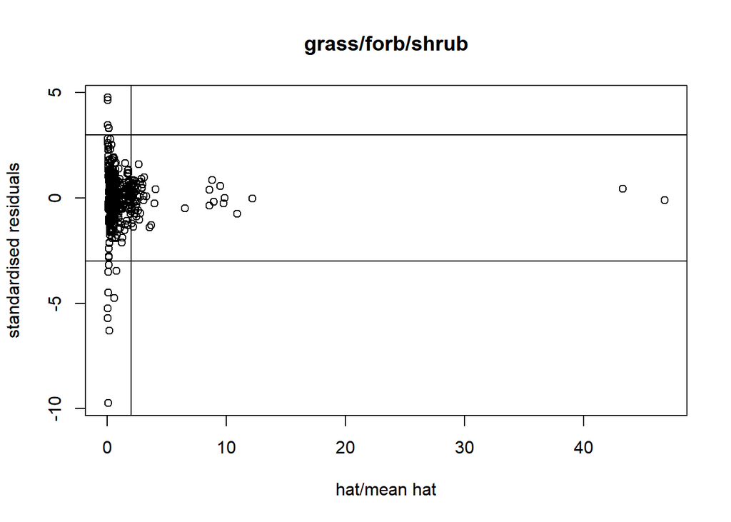

```r
rstn <- rstandard(nt.mv.pgfs)
hat <- hatvalues(nt.mv.pgfs) / mean(hatvalues(nt.mv.pgfs))
plot(hat, rstn$resid,
     xlab = "hat/mean hat",
     ylab = "standardised residuals",
     main = "grass/forb/shrub")
abline(h = -3)
abline(h = 3)
abline(v = 2)
```

## Viechtbauer method

Estimate

```r
rstd.pgfs <- rstudent(nt.mv.pgfs, reestimate = FALSE, progbar = TRUE)
```

```r
x <- subset(rstd.pgfs, rstd.pgfs$resid > 1.96)
y <- subset(rstd.pgfs, rstd.pgfs$resid < -1.96)
length(x[["resid"]]) + length(y[["resid"]])
```

```
## [1] 31
```

```r
nt.mv.pgfs$k / 10
```

```
## [1] 65.5
```

```r
dfb.pgfs <- dfbetas.rma.mv(nt.mv.pgfs, reestimate = FALSE, progbar = TRUE)
```

```r
summary(dfb.pgfs)
```

```
##  factor.plant_gfs.forb factor.plant_gfs.graminoid factor.plant_gfs.shrub
##  Min.   :-1.431e-01    Min.   :-0.1869606         Min.   :-0.3105032
##  1st Qu.:-1.040e-02    1st Qu.:-0.0119132         1st Qu.:-0.0040899
##  Median :-1.228e-04    Median : 0.0002151         Median :-0.0000260
##  Mean   :-8.870e-06    Mean   :-0.0004865         Mean   : 0.0000436
##  3rd Qu.: 1.068e-02    3rd Qu.: 0.0103135         3rd Qu.: 0.0048618
##  Max.   : 1.833e-01    Max.   : 0.1317652         Max.   : 0.3178659
##  factor.plant_gfs.subshrub factor.plant_gfs.unknown
##  Min.   :-0.7025521        Min.   :-0.2328651
##  1st Qu.:-0.0031869        1st Qu.:-0.0035080
##  Median :-0.0001101        Median : 0.0001253
##  Mean   : 0.0000368        Mean   :-0.0005147
##  3rd Qu.: 0.0027846        3rd Qu.: 0.0040050
##  Max.   : 0.8754501        Max.   : 0.1632292
```

# Annual/perennial and grass/forb/shrub

```r
nt.mv.papgfs <- rma.mv(yi = yi,
                       V = vi,
                       random = ~ 1 | exp_ID / obs_ID,
                       data = nt,
                       mods = ~ factor(plant_apgfs) - 1)
```

## Habeck method

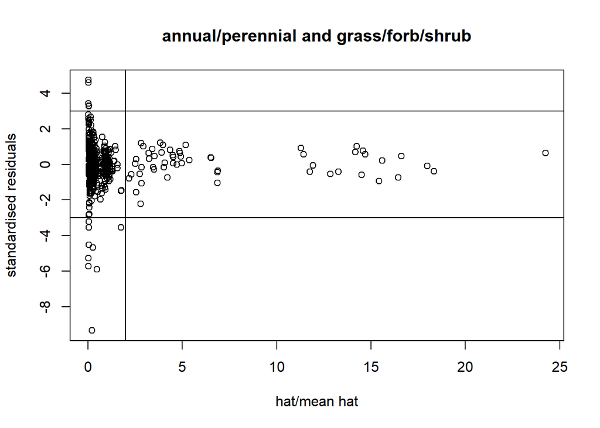

```r
rstn <- rstandard(nt.mv.papgfs)
hat <- hatvalues(nt.mv.papgfs) / mean(hatvalues(nt.mv.papgfs))
plot(hat, rstn$resid,
     xlab = "hat/mean hat",
     ylab = "standardised residuals",
     main = "annual/perennial and grass/forb/shrub")
abline(h = -3)
abline(h = 3)
abline(v = 2)
```

## Viechtbauer method

Estimate

```r
rstd.papgfs <- rstudent(nt.mv.papgfs, reestimate = FALSE, progbar = TRUE)
```

```r
x <- subset(rstd.papgfs, rstd.papgfs$resid > 1.96)
y <- subset(rstd.papgfs, rstd.papgfs$resid < -1.96)
length(x[["resid"]]) + length(y[["resid"]])
```

```
## [1] 33
```

```r
nt.mv.papgfs$k / 10
```

```
## [1] 65.5
```

```r
dfb.papgfs <- dfbetas.rma.mv(nt.mv.papgfs, reestimate = FALSE, progbar = TRUE)
```

```r
summary(dfb.papgfs)
```

```
##  factor.plant_apgfs.annual.forb factor.plant_apgfs.annual.graminoid
##  Min.   :-0.1897015             Min.   :-0.4299317
##  1st Qu.:-0.0048294             1st Qu.:-0.0018419
##  Median :-0.0001246             Median : 0.0000253
##  Mean   : 0.0000054             Mean   :-0.0003604
##  3rd Qu.: 0.0044521             3rd Qu.: 0.0018146
##  Max.   : 0.4420967             Max.   : 0.4542903
##  factor.plant_apgfs.annual.unknown factor.plant_apgfs.biennial.forb
##  Min.   :-0.3372918                Min.   :-0.7706116
##  1st Qu.:-0.0003586                1st Qu.:-0.0014020
##  Median : 0.0000092                Median :-0.0000040
##  Mean   : 0.0011656                Mean   : 0.0002024
##  3rd Qu.: 0.0003287                3rd Qu.: 0.0015919
##  Max.   : 1.3707897                Max.   : 0.8088052
##  factor.plant_apgfs.perennial.forb factor.plant_apgfs.perennial.graminoid
##  Min.   :-0.173327                 Min.   :-0.1969314
##  1st Qu.:-0.006794                 1st Qu.:-0.0111419
##  Median : 0.000000                 Median : 0.0001003
##  Mean   :-0.000220                 Mean   :-0.0005494
##  3rd Qu.: 0.008969                 3rd Qu.: 0.0094289
##  Max.   : 0.108942                 Max.   : 0.1362626
##  factor.plant_apgfs.perennial.shrub factor.plant_apgfs.perennial.subshrub
##  Min.   :-0.2831433                 Min.   :-0.7554253
##  1st Qu.:-0.0040982                 1st Qu.:-0.0028688
##  Median :-0.0000639                 Median :-0.0000004
##  Mean   :-0.0001680                 Mean   :-0.0001074
##  3rd Qu.: 0.0047617                 3rd Qu.: 0.0028450
##  Max.   : 0.3206081                 Max.   : 0.8417334
##  factor.plant_apgfs.perennial.unknown factor.plant_apgfs.unknown.forb
##  Min.   :-0.1706400                   Min.   :-0.2944101
##  1st Qu.:-0.0047629                   1st Qu.:-0.0018527
##  Median : 0.0001225                   Median : 0.0000000
##  Mean   :-0.0005464                   Mean   : 0.0007299
##  3rd Qu.: 0.0043661                   3rd Qu.: 0.0014787
##  Max.   : 0.1790876                   Max.   : 0.7849635
##  factor.plant_apgfs.unknown.graminoid factor.plant_apgfs.unknown.shrub
##  Min.   :-0.5867914                   Min.   :-0.3917688
##  1st Qu.:-0.0012195                   1st Qu.:-0.0003244
##  Median :-0.0000031                   Median :-0.0000009
##  Mean   : 0.0004677                   Mean   : 0.0005845
##  3rd Qu.: 0.0011343                   3rd Qu.: 0.0002731
##  Max.   : 1.0050802                   Max.   : 0.4986338
##  factor.plant_apgfs.unknown.unknown
##  Min.   :-0.873942
##  1st Qu.: 0.000000
##  Median : 0.000000
##  Mean   :-0.001135
##  3rd Qu.: 0.000000
##  Max.   : 0.272484
```

```r
subset(dfb.papgfs, dfb.papgfs$factor.plant_apgfs.annual.unknown > 1) # 331
```

```
##     factor.plant_apgfs.annual.forb factor.plant_apgfs.annual.graminoid
## 331                    -0.01255757                        -0.005094372
##     factor.plant_apgfs.annual.unknown factor.plant_apgfs.biennial.forb
## 331                           1.37079                     -0.003980409
##     factor.plant_apgfs.perennial.forb factor.plant_apgfs.perennial.graminoid
## 331                       -0.02570102                            -0.02992226
##     factor.plant_apgfs.perennial.shrub factor.plant_apgfs.perennial.subshrub
## 331                        -0.01685074                          -0.007644313
##     factor.plant_apgfs.perennial.unknown factor.plant_apgfs.unknown.forb
## 331                           -0.1112168                    -0.005625388
##     factor.plant_apgfs.unknown.graminoid factor.plant_apgfs.unknown.shrub
## 331                         -0.003730372                     -0.001006547
##     factor.plant_apgfs.unknown.unknown
## 331                                  0
```

```r
subset(dfb.papgfs, dfb.papgfs$factor.plant_apgfs.unknown.graminoid > 1) # 335
```

```
##     factor.plant_apgfs.annual.forb factor.plant_apgfs.annual.graminoid
## 335                     -0.1741458                        -0.003926815
##     factor.plant_apgfs.annual.unknown factor.plant_apgfs.biennial.forb
## 335                      -0.003748713                      -0.02853305
##     factor.plant_apgfs.perennial.forb factor.plant_apgfs.perennial.graminoid
## 335                        -0.1690714                             -0.1290845
##     factor.plant_apgfs.perennial.shrub factor.plant_apgfs.perennial.subshrub
## 335                         -0.1529344                             -0.101706
##     factor.plant_apgfs.perennial.unknown factor.plant_apgfs.unknown.forb
## 335                           -0.0497867                       0.1544671
##     factor.plant_apgfs.unknown.graminoid factor.plant_apgfs.unknown.shrub
## 335                              1.00508                        0.1481872
##     factor.plant_apgfs.unknown.unknown
## 335                                  0
```

```r
x$slab # not influential
```

```
##  [1]   7   9  15  26  28  38  39 212 225 300 303 306 508 527 576 590
```

```r
nt[c(331, 335), c("paper", "obs_ID", "plant_apgfs")]
```

```
##
##           paper obs_ID       plant_apgfs
## 331   Rowe_2009   1618    annual unknown
## 335 Sandel_2011   1628 unknown graminoid
```

- Observations 1618 and 1628 are influential, but not outliers.

# Plot size

```r
nt.mv.plotc <- rma.mv(yi = yi,
                       V = vi,
                       random = ~ 1 | exp_ID / obs_ID,
                       data = nt,
                       mods = ~ factor(plotc) - 1)
```

## Habeck method

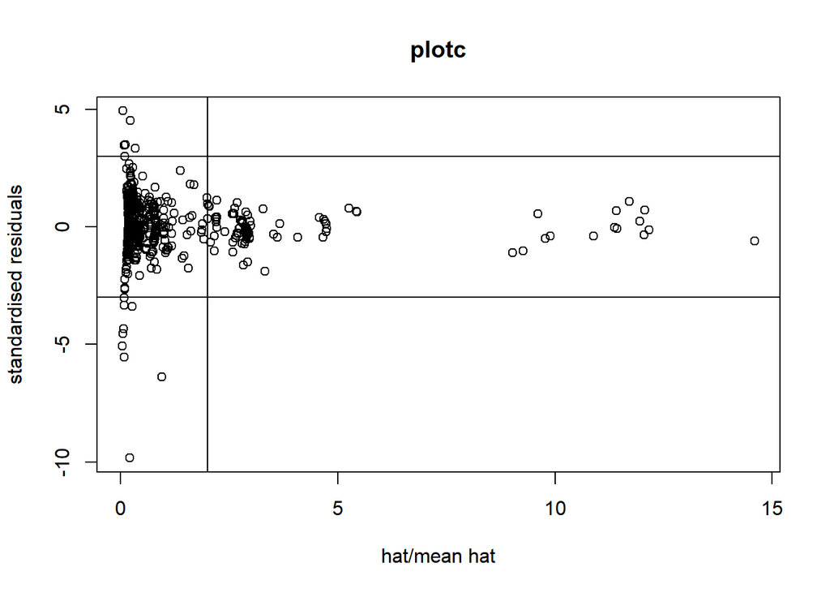

```r
rstn <- rstandard(nt.mv.plotc)
hat <- hatvalues(nt.mv.plotc) / mean(hatvalues(nt.mv.plotc))
plot(hat, rstn$resid,
     xlab = "hat/mean hat",
     ylab = "standardised residuals",
     main = "plotc")
abline(h = -3)
abline(h = 3)
abline(v = 2)
```

## Viechtbauer method

Estimate

```r
rstd.plotc <- rstudent(nt.mv.plotc, reestimate = FALSE, progbar = TRUE)
```

```r
x <- subset(rstd.plotc, rstd.plotc$resid > 1.96)
y <- subset(rstd.plotc, rstd.plotc$resid < -1.96)
length(x[["resid"]]) + length(y[["resid"]])
```

```
## [1] 30
```

```r
nt.mv.plotc$k / 10
```

```
## [1] 64.9
```

```r
dfb.plotc <- dfbetas.rma.mv(nt.mv.plotc, reestimate = FALSE, progbar = TRUE)
```

```r
summary(dfb.plotc)
```

```
##  factor.plotc..1      factor.plotc.1       factor.plotc.1.3.3.75
##  Min.   :-0.1035592   Min.   :-0.1832996   Min.   :-0.2401483
##  1st Qu.: 0.0000000   1st Qu.: 0.0000000   1st Qu.: 0.0000000
##  Median : 0.0000000   Median : 0.0000000   Median : 0.0000000
##  Mean   :-0.0000821   Mean   :-0.0001875   Mean   :-0.0008233
##  3rd Qu.: 0.0000000   3rd Qu.: 0.0000000   3rd Qu.: 0.0000000
##  Max.   : 0.1559349   Max.   : 0.2917846   Max.   : 0.1670130
##  factor.plotc.4       factor.plotc.6.9     factor.plotc.12.5.16
##  Min.   :-0.6022595   Min.   :-0.8104677   Min.   :-0.092950
##  1st Qu.: 0.0000000   1st Qu.: 0.0000000   1st Qu.: 0.000000
##  Median : 0.0000000   Median : 0.0000000   Median : 0.000000
##  Mean   :-0.0007624   Mean   :-0.0008885   Mean   : 0.000747
##  3rd Qu.: 0.0000000   3rd Qu.: 0.0000000   3rd Qu.: 0.000000
##  Max.   : 0.3063928   Max.   : 0.1946284   Max.   : 0.211477
##  factor.plotc.25      factor.plotc.28.50   factor.plotc.75
##  Min.   :-0.4407474   Min.   :-0.4829216   Min.   :-0.2795078
##  1st Qu.: 0.0000000   1st Qu.: 0.0000000   1st Qu.: 0.0000000
##  Median : 0.0000000   Median : 0.0000000   Median : 0.0000000
##  Mean   :-0.0004466   Mean   : 0.0000808   Mean   : 0.0000705
##  3rd Qu.: 0.0000000   3rd Qu.: 0.0000000   3rd Qu.: 0.0000000
##  Max.   : 0.2010641   Max.   : 0.6344966   Max.   : 0.4842909
##  factor.plotc..100
##  Min.   :-1.097e-01
##  1st Qu.: 0.000e+00
##  Median : 0.000e+00
##  Mean   : 9.650e-06
##  3rd Qu.: 0.000e+00
##  Max.   : 1.324e-01
```

# Seeding of native

```r
nt.mv.seedn <- rma.mv(yi = yi,
                      V = vi,
                      random = ~ 1 | exp_ID / obs_ID,
                      data = nt,
                      mods = ~ factor(seedn) - 1)
```

## Habeck method

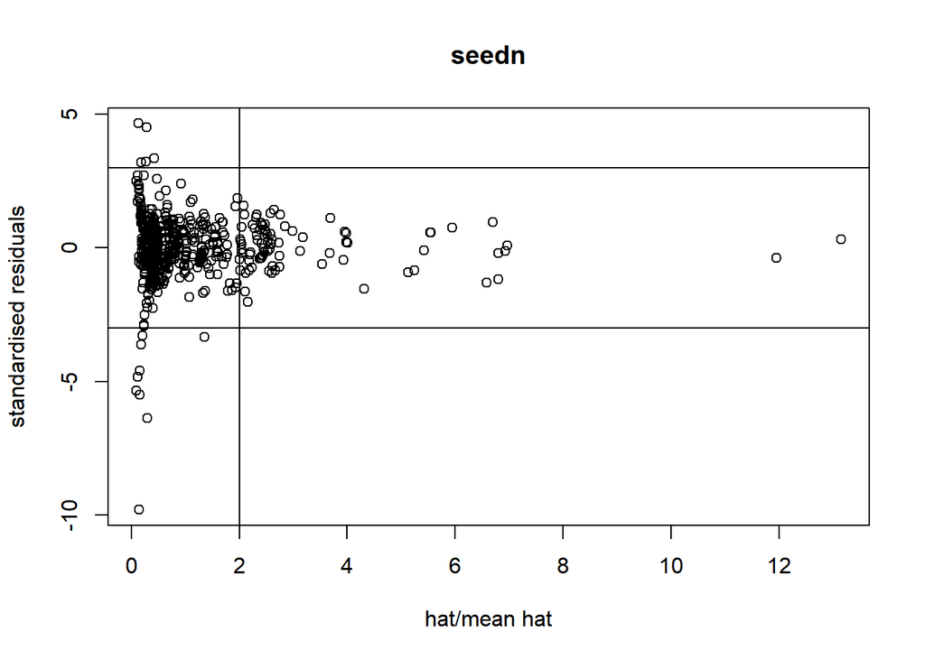

```r
rstn <- rstandard(nt.mv.seedn)
hat <- hatvalues(nt.mv.seedn) / mean(hatvalues(nt.mv.seedn))
plot(hat, rstn$resid,
     xlab = "hat/mean hat",
     ylab = "standardised residuals",
     main = "seedn")
abline(h = -3)
abline(h = 3)
abline(v = 2)
```

## Viechtbauer method

Estimate

```r
rstd.seedn <- rstudent(nt.mv.seedn, reestimate = FALSE, progbar = TRUE)
```

```r
x <- subset(rstd.seedn, rstd.seedn$resid > 1.96)
y <- subset(rstd.seedn, rstd.seedn$resid < -1.96)
length(x[["resid"]]) + length(y[["resid"]])
```

```
## [1] 32
```

```r
nt.mv.seedn$k / 10
```

```
## [1] 65.5
```

```r
dfb.seedn <- dfbetas.rma.mv(nt.mv.seedn, reestimate = FALSE, progbar = TRUE)
```

```r
summary(dfb.seedn)
```

```
##  factor.seedn.native.not.seeded factor.seedn.native.seeded
##  Min.   :-2.509e-01             Min.   :-1.163e-01
##  1st Qu.:-1.705e-03             1st Qu.:-9.351e-03
##  Median :-2.428e-05             Median :-3.028e-04
##  Mean   :-4.682e-04             Mean   :-8.413e-05
##  3rd Qu.: 1.507e-03             3rd Qu.: 8.452e-03
##  Max.   : 2.251e-01             Max.   : 1.359e-01
```

# Model selection 14

```r
nt.ms14 <- nt[!apply(nt[ , c("region", "dlc", "C_type", "cratc", "capt", "plant_apgfs", "plotc")], 1, anyNA), ]

nt.mv.ms14 <- rma.mv(yi = yi,
                     V = vi,
                     random = ~ 1 | exp_ID / obs_ID,
                     data = nt.ms14,
                     mods = ~ 1 + dlc + cratc + region + C_type + plant_apgfs)
```

## Habeck method

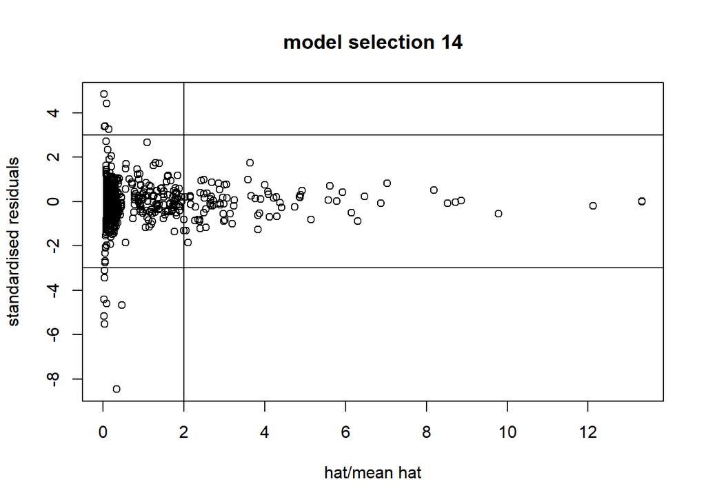

```r
rstn <- rstandard(nt.mv.ms14)
hat <- hatvalues(nt.mv.ms14) / mean(hatvalues(nt.mv.ms14))
plot(hat, rstn$resid,
     xlab = "hat/mean hat",
     ylab = "standardised residuals",
     main = "model selection 14")
abline(h = -3)
abline(h = 3)
abline(v = 2)
```

## Viechtbauer method

Estimate

```r
rstd.ms14 <- rstudent(nt.mv.ms14, reestimate = FALSE, progbar = TRUE)
```

```r
x <- subset(rstd.ms14, rstd.ms14$resid > 1.96)
y <- subset(rstd.ms14, rstd.ms14$resid < -1.96)
length(x[["resid"]]) + length(y[["resid"]])
```

```
## [1] 27
```

```r
nt.mv.ms14$k / 10
```

```
## [1] 64
```

```r
dfb.ms14 <- dfbetas.rma.mv(nt.mv.ms14, reestimate = FALSE, progbar = TRUE)
```

```r
summary(dfb.ms14)
```

```
##     intrcpt                dlc2               dlc3.3.5
##  Min.   :-0.4155958   Min.   :-0.4243864   Min.   :-1.9436504
##  1st Qu.:-0.0049883   1st Qu.:-0.0031107   1st Qu.:-0.0028736
##  Median : 0.0000116   Median : 0.0000000   Median : 0.0001296
##  Mean   : 0.0016798   Mean   :-0.0009837   Mean   : 0.0006069
##  3rd Qu.: 0.0048385   3rd Qu.: 0.0041251   3rd Qu.: 0.0050989
##  Max.   : 1.2956168   Max.   : 0.3852753   Max.   : 1.9706307
##  NA's   :3            NA's   :3            NA's   :3
##      dlc4.6              dlc7.12             dlc13.18
##  Min.   :-0.6768867   Min.   :-0.319724   Min.   :-0.3974334
##  1st Qu.:-0.0028166   1st Qu.:-0.004994   1st Qu.:-0.0034263
##  Median : 0.0000978   Median : 0.000000   Median : 0.0002613
##  Mean   : 0.0007014   Mean   : 0.001293   Mean   : 0.0009572
##  3rd Qu.: 0.0030521   3rd Qu.: 0.004317   3rd Qu.: 0.0035305
##  Max.   : 0.3338465   Max.   : 0.496479   Max.   : 0.3517890
##  NA's   :3            NA's   :3           NA's   :3
##     dlc19.24             dlc36.49             dlc.100
##  Min.   :-0.3722328   Min.   :-0.2882320   Min.   :-0.6397914
##  1st Qu.:-0.0043334   1st Qu.:-0.0024408   1st Qu.:-0.0020931
##  Median : 0.0001149   Median : 0.0000722   Median : 0.0000586
##  Mean   : 0.0011616   Mean   :-0.0005353   Mean   : 0.0009312
##  3rd Qu.: 0.0044266   3rd Qu.: 0.0030787   3rd Qu.: 0.0024884
##  Max.   : 0.5180786   Max.   : 0.1987965   Max.   : 0.4766363
##  NA's   :3            NA's   :3            NA's   :3
##   cratc133.160         cratc174.200         cratc210.300
##  Min.   :-0.4157604   Min.   :-0.7952271   Min.   :-0.1695175
##  1st Qu.:-0.0029034   1st Qu.:-0.0042315   1st Qu.:-0.0023623
##  Median :-0.0000213   Median : 0.0001822   Median : 0.0000000
##  Mean   :-0.0012256   Mean   :-0.0016723   Mean   :-0.0002039
##  3rd Qu.: 0.0032896   3rd Qu.: 0.0041630   3rd Qu.: 0.0028468
##  Max.   : 0.5048785   Max.   : 0.3885702   Max.   : 0.3236543
##  NA's   :3            NA's   :3            NA's   :3
##   cratc330.400         cratc420.500         cratc506.600
##  Min.   :-0.3030917   Min.   :-1.3094167   Min.   :-0.5973475
##  1st Qu.:-0.0029374   1st Qu.:-0.0033058   1st Qu.:-0.0026833
##  Median : 0.0001036   Median : 0.0000556   Median : 0.0000175
##  Mean   :-0.0010421   Mean   :-0.0033390   Mean   :-0.0019453
##  3rd Qu.: 0.0030586   3rd Qu.: 0.0043330   3rd Qu.: 0.0022628
##  Max.   : 0.2587245   Max.   : 0.2384249   Max.   : 0.5626641
##  NA's   :3            NA's   :3            NA's   :3
```

[output cut: 89 more lines]

```
##  Min.   :-0.3304948      Min.   :-0.4020215           Min.   :-0.6727826
##  1st Qu.:-0.0030597      1st Qu.:-0.0038260           1st Qu.:-0.0023289
##  Median :-0.0000752      Median :-0.0000914           Median :-0.0000360
##  Mean   :-0.0003370      Mean   :-0.0007313           Mean   :-0.0005978
##  3rd Qu.: 0.0031317      3rd Qu.: 0.0035080           3rd Qu.: 0.0023000
##  Max.   : 0.8023222      Max.   : 1.0935777           Max.   : 0.5071199
##  NA's   :3               NA's   :3                    NA's   :3
##  plant_apgfsunknown.unknown
##  Min.   :-2.8009224
##  1st Qu.:-0.0055973
##  Median :-0.0001571
##  Mean   :-0.0023052
##  3rd Qu.: 0.0055363
##  Max.   : 1.6165896
##  NA's   :3
```

```r
subset(dfb.ms14, dfb.ms14$intrcpt > 1) # 351
```

```
##      intrcpt       dlc2 dlc3.3.5    dlc4.6   dlc7.12  dlc13.18  dlc19.24
## 351 1.295617 -0.4243864 1.970631 0.3245356 0.4964793 0.2902002 0.5180786
##      dlc36.49   dlc.100 cratc133.160 cratc174.200 cratc210.300 cratc330.400
## 351 -0.288232 0.4766363   -0.4157604   -0.7952271   0.03336644   -0.3030917
##     cratc420.500 cratc506.600 cratc620.700 cratc714.999 cratc1000.1330
## 351    -1.309417   -0.5973475   -0.5206656   -0.3985327     -0.2809612
##     cratc1600.2000 cratc2110.3000 cratc3346.5000 cratc.5000
## 351     -0.3401364      -0.287805     -0.3691462   -1.79477
##     regioncoastal.CA..USA regionGreat.Basin..USA regionGreat.Plains..USA
## 351            -0.6777948             -0.3984856              -0.2121796
##     regionMidwest..USA regionnortheast.USA regionPacific.Northwest..USA
## 351         -0.8355635          -0.2969912                   -0.1598232
##     regionRocky.Mountains..USA regionsoutheast.Australia regionsouthwest.USA
## 351                 -0.4456846               -0.01977195          -0.4474823
##     C_typelignin C_typelignin.AND.sucrose C_typesawdust C_typesucrose
## 351    -1.111246                 -1.03941     -1.142926     -1.334074
##     C_typesucrose.AND.sawdust plant_apgfsannual.graminoid
## 351                 -1.089278                 -0.03277905
##     plant_apgfsannual.unknown plant_apgfsbiennial.forb
## 351                 0.2489256               0.02544025
##     plant_apgfsperennial.forb plant_apgfsperennial.graminoid
## 351                 0.0217089                     0.01795133
##     plant_apgfsperennial.shrub plant_apgfsperennial.subshrub
## 351                0.003164185                  -0.008677939
##     plant_apgfsperennial.unknown plant_apgfsunknown.forb
## 351                   0.04122699              -0.3304948
##     plant_apgfsunknown.graminoid plant_apgfsunknown.shrub
## 351                   -0.4020215               -0.2708244
##     plant_apgfsunknown.unknown
## 351                  -2.800922
```

```r
subset(dfb.ms14, dfb.ms14$dlc3.3.5 > 1) # 351
```

```
##      intrcpt       dlc2 dlc3.3.5    dlc4.6   dlc7.12  dlc13.18  dlc19.24
## 351 1.295617 -0.4243864 1.970631 0.3245356 0.4964793 0.2902002 0.5180786
##      dlc36.49   dlc.100 cratc133.160 cratc174.200 cratc210.300 cratc330.400
## 351 -0.288232 0.4766363   -0.4157604   -0.7952271   0.03336644   -0.3030917
##     cratc420.500 cratc506.600 cratc620.700 cratc714.999 cratc1000.1330
## 351    -1.309417   -0.5973475   -0.5206656   -0.3985327     -0.2809612
##     cratc1600.2000 cratc2110.3000 cratc3346.5000 cratc.5000
## 351     -0.3401364      -0.287805     -0.3691462   -1.79477
##     regioncoastal.CA..USA regionGreat.Basin..USA regionGreat.Plains..USA
## 351            -0.6777948             -0.3984856              -0.2121796
##     regionMidwest..USA regionnortheast.USA regionPacific.Northwest..USA
## 351         -0.8355635          -0.2969912                   -0.1598232
##     regionRocky.Mountains..USA regionsoutheast.Australia regionsouthwest.USA
## 351                 -0.4456846               -0.01977195          -0.4474823
##     C_typelignin C_typelignin.AND.sucrose C_typesawdust C_typesucrose
## 351    -1.111246                 -1.03941     -1.142926     -1.334074
##     C_typesucrose.AND.sawdust plant_apgfsannual.graminoid
## 351                 -1.089278                 -0.03277905
##     plant_apgfsannual.unknown plant_apgfsbiennial.forb
## 351                 0.2489256               0.02544025
##     plant_apgfsperennial.forb plant_apgfsperennial.graminoid
## 351                 0.0217089                     0.01795133
##     plant_apgfsperennial.shrub plant_apgfsperennial.subshrub
## 351                0.003164185                  -0.008677939
##     plant_apgfsperennial.unknown plant_apgfsunknown.forb
## 351                   0.04122699              -0.3304948
##     plant_apgfsunknown.graminoid plant_apgfsunknown.shrub
## 351                   -0.4020215               -0.2708244
##     plant_apgfsunknown.unknown
## 351                  -2.800922
```

```r
subset(dfb.ms14, dfb.ms14$cratc.5000 > 1) # 637
```

```
##        intrcpt       dlc2 dlc3.3.5    dlc4.6   dlc7.12  dlc13.18  dlc19.24
## 637 -0.3996866 -0.4243864 -1.94365 0.3245356 0.4964793 0.2902002 0.5180786
##      dlc36.49   dlc.100 cratc133.160 cratc174.200 cratc210.300 cratc330.400
## 637 -0.288232 0.4766363   -0.4157604   -0.7952271   0.03336644   -0.3030917
##     cratc420.500 cratc506.600 cratc620.700 cratc714.999 cratc1000.1330
## 637    -1.309417   -0.5973475   -0.5206656   -0.3985327     -0.2809612
##     cratc1600.2000 cratc2110.3000 cratc3346.5000 cratc.5000
## 637     -0.3401364      -0.287805     -0.3691462   1.569233
##     regioncoastal.CA..USA regionGreat.Basin..USA regionGreat.Plains..USA
## 637            -0.6777948             -0.3984856              -0.2121796
##     regionMidwest..USA regionnortheast.USA regionPacific.Northwest..USA
## 637         -0.8355635          -0.2969912                   -0.1598232
##     regionRocky.Mountains..USA regionsoutheast.Australia regionsouthwest.USA
## 637                 -0.4456846               -0.01977195          -0.4474823
##     C_typelignin C_typelignin.AND.sucrose C_typesawdust C_typesucrose
## 637    0.7804637                0.7300109      0.857626      0.770545
##     C_typesucrose.AND.sawdust plant_apgfsannual.graminoid
## 637                  0.930748                 -0.03277905
##     plant_apgfsannual.unknown plant_apgfsbiennial.forb
## 637                 0.2489256               0.02544025
##     plant_apgfsperennial.forb plant_apgfsperennial.graminoid
## 637                 0.0217089                     0.01795133
##     plant_apgfsperennial.shrub plant_apgfsperennial.subshrub
## 637                0.003164185                  -0.008677939
##     plant_apgfsperennial.unknown plant_apgfsunknown.forb
## 637                   0.04122699              -0.3304948
##     plant_apgfsunknown.graminoid plant_apgfsunknown.shrub
## 637                   -0.4020215               -0.2708244
##     plant_apgfsunknown.unknown
## 637                    1.61659
```

```r
subset(dfb.ms14, dfb.ms14$plant_apgfsunknown.graminoid > 1) # 325
```

```
##        intrcpt      dlc2    dlc3.3.5     dlc4.6    dlc7.12    dlc13.18
## 325 -0.1533202 0.2057633 -0.03118762 0.03646137 -0.2276893 -0.09996823
##       dlc19.24   dlc36.49    dlc.100 cratc133.160 cratc174.200 cratc210.300
## 325 -0.1583227 0.09492437 -0.0640251     0.126688    0.2490503   0.01705505
##     cratc330.400 cratc420.500 cratc506.600 cratc620.700 cratc714.999
## 325  -0.03469667    0.1098315   -0.1511908 -0.005566721   0.05221142
##     cratc1000.1330 cratc1600.2000 cratc2110.3000 cratc3346.5000 cratc.5000
## 325     -0.0310574     -0.1319773    -0.03683269    -0.05091809 -0.1843784
##     regioncoastal.CA..USA regionGreat.Basin..USA regionGreat.Plains..USA
## 325             0.1536529              0.2748387               0.2013337
##     regionMidwest..USA regionnortheast.USA regionPacific.Northwest..USA
## 325          0.3611176           0.1043256                    0.2230548
##     regionRocky.Mountains..USA regionsoutheast.Australia regionsouthwest.USA
## 325                  0.2114817                 0.1492092           0.1696522
##     C_typelignin C_typelignin.AND.sucrose C_typesawdust C_typesucrose
## 325   0.01556242                0.0145564    0.03401601   0.002486427
##     C_typesucrose.AND.sawdust plant_apgfsannual.graminoid
## 325                0.01765694                   0.0831171
##     plant_apgfsannual.unknown plant_apgfsbiennial.forb
## 325               -0.03427075               0.04651946
##     plant_apgfsperennial.forb plant_apgfsperennial.graminoid
## 325                 0.0677052                     0.09883827
##     plant_apgfsperennial.shrub plant_apgfsperennial.subshrub
## 325                 0.02080807                  -0.005309259
##     plant_apgfsperennial.unknown plant_apgfsunknown.forb
## 325                   0.01946449               0.3643814
##     plant_apgfsunknown.graminoid plant_apgfsunknown.shrub
## 325                     1.093578                0.2790033
##     plant_apgfsunknown.unknown
## 325                 0.06945377
```

```r
subset(dfb.ms14, dfb.ms14$plant_apgfsunknown.unknown > 1) # 637
```

```
##        intrcpt       dlc2 dlc3.3.5    dlc4.6   dlc7.12  dlc13.18  dlc19.24
## 637 -0.3996866 -0.4243864 -1.94365 0.3245356 0.4964793 0.2902002 0.5180786
##      dlc36.49   dlc.100 cratc133.160 cratc174.200 cratc210.300 cratc330.400
## 637 -0.288232 0.4766363   -0.4157604   -0.7952271   0.03336644   -0.3030917
##     cratc420.500 cratc506.600 cratc620.700 cratc714.999 cratc1000.1330
## 637    -1.309417   -0.5973475   -0.5206656   -0.3985327     -0.2809612
##     cratc1600.2000 cratc2110.3000 cratc3346.5000 cratc.5000
## 637     -0.3401364      -0.287805     -0.3691462   1.569233
##     regioncoastal.CA..USA regionGreat.Basin..USA regionGreat.Plains..USA
## 637            -0.6777948             -0.3984856              -0.2121796
##     regionMidwest..USA regionnortheast.USA regionPacific.Northwest..USA
## 637         -0.8355635          -0.2969912                   -0.1598232
##     regionRocky.Mountains..USA regionsoutheast.Australia regionsouthwest.USA
## 637                 -0.4456846               -0.01977195          -0.4474823
##     C_typelignin C_typelignin.AND.sucrose C_typesawdust C_typesucrose
## 637    0.7804637                0.7300109      0.857626      0.770545
##     C_typesucrose.AND.sawdust plant_apgfsannual.graminoid
## 637                  0.930748                 -0.03277905
##     plant_apgfsannual.unknown plant_apgfsbiennial.forb
## 637                 0.2489256               0.02544025
##     plant_apgfsperennial.forb plant_apgfsperennial.graminoid
## 637                 0.0217089                     0.01795133
##     plant_apgfsperennial.shrub plant_apgfsperennial.subshrub
## 637                0.003164185                  -0.008677939
##     plant_apgfsperennial.unknown plant_apgfsunknown.forb
## 637                   0.04122699              -0.3304948
##     plant_apgfsunknown.graminoid plant_apgfsunknown.shrub
## 637                   -0.4020215               -0.2708244
##     plant_apgfsunknown.unknown
## 637                    1.61659
```

```r
x$slab # none
```

```
##  [1]   7 206 244 291 294 297 493 512 561 575
```

```r
subset(dfb.ms14, dfb.ms14$dlc3.3.5 < -1) # 637
```

```
##        intrcpt       dlc2 dlc3.3.5    dlc4.6   dlc7.12  dlc13.18  dlc19.24
## 637 -0.3996866 -0.4243864 -1.94365 0.3245356 0.4964793 0.2902002 0.5180786
##      dlc36.49   dlc.100 cratc133.160 cratc174.200 cratc210.300 cratc330.400
## 637 -0.288232 0.4766363   -0.4157604   -0.7952271   0.03336644   -0.3030917
##     cratc420.500 cratc506.600 cratc620.700 cratc714.999 cratc1000.1330
## 637    -1.309417   -0.5973475   -0.5206656   -0.3985327     -0.2809612
##     cratc1600.2000 cratc2110.3000 cratc3346.5000 cratc.5000
## 637     -0.3401364      -0.287805     -0.3691462   1.569233
##     regioncoastal.CA..USA regionGreat.Basin..USA regionGreat.Plains..USA
## 637            -0.6777948             -0.3984856              -0.2121796
##     regionMidwest..USA regionnortheast.USA regionPacific.Northwest..USA
## 637         -0.8355635          -0.2969912                   -0.1598232
##     regionRocky.Mountains..USA regionsoutheast.Australia regionsouthwest.USA
## 637                 -0.4456846               -0.01977195          -0.4474823
##     C_typelignin C_typelignin.AND.sucrose C_typesawdust C_typesucrose
## 637    0.7804637                0.7300109      0.857626      0.770545
##     C_typesucrose.AND.sawdust plant_apgfsannual.graminoid
## 637                  0.930748                 -0.03277905
##     plant_apgfsannual.unknown plant_apgfsbiennial.forb
## 637                 0.2489256               0.02544025
##     plant_apgfsperennial.forb plant_apgfsperennial.graminoid
## 637                 0.0217089                     0.01795133
##     plant_apgfsperennial.shrub plant_apgfsperennial.subshrub
## 637                0.003164185                  -0.008677939
##     plant_apgfsperennial.unknown plant_apgfsunknown.forb
## 637                   0.04122699              -0.3304948
##     plant_apgfsunknown.graminoid plant_apgfsunknown.shrub
## 637                   -0.4020215               -0.2708244
##     plant_apgfsunknown.unknown
## 637                    1.61659
```

```r
subset(dfb.ms14, dfb.ms14$cratc420.500 < -1) # 351, 637
```

```
##        intrcpt       dlc2  dlc3.3.5    dlc4.6   dlc7.12  dlc13.18  dlc19.24
## 351  1.2956168 -0.4243864  1.970631 0.3245356 0.4964793 0.2902002 0.5180786
## 637 -0.3996866 -0.4243864 -1.943650 0.3245356 0.4964793 0.2902002 0.5180786
##      dlc36.49   dlc.100 cratc133.160 cratc174.200 cratc210.300 cratc330.400
## 351 -0.288232 0.4766363   -0.4157604   -0.7952271   0.03336644   -0.3030917
## 637 -0.288232 0.4766363   -0.4157604   -0.7952271   0.03336644   -0.3030917
##     cratc420.500 cratc506.600 cratc620.700 cratc714.999 cratc1000.1330
## 351    -1.309417   -0.5973475   -0.5206656   -0.3985327     -0.2809612
## 637    -1.309417   -0.5973475   -0.5206656   -0.3985327     -0.2809612
##     cratc1600.2000 cratc2110.3000 cratc3346.5000 cratc.5000
## 351     -0.3401364      -0.287805     -0.3691462  -1.794770
## 637     -0.3401364      -0.287805     -0.3691462   1.569233
##     regioncoastal.CA..USA regionGreat.Basin..USA regionGreat.Plains..USA
## 351            -0.6777948             -0.3984856              -0.2121796
## 637            -0.6777948             -0.3984856              -0.2121796
##     regionMidwest..USA regionnortheast.USA regionPacific.Northwest..USA
## 351         -0.8355635          -0.2969912                   -0.1598232
## 637         -0.8355635          -0.2969912                   -0.1598232
##     regionRocky.Mountains..USA regionsoutheast.Australia regionsouthwest.USA
## 351                 -0.4456846               -0.01977195          -0.4474823
## 637                 -0.4456846               -0.01977195          -0.4474823
##     C_typelignin C_typelignin.AND.sucrose C_typesawdust C_typesucrose
## 351   -1.1112465               -1.0394103     -1.142926     -1.334074
## 637    0.7804637                0.7300109      0.857626      0.770545
##     C_typesucrose.AND.sawdust plant_apgfsannual.graminoid
## 351                 -1.089278                 -0.03277905
## 637                  0.930748                 -0.03277905
##     plant_apgfsannual.unknown plant_apgfsbiennial.forb
## 351                 0.2489256               0.02544025
## 637                 0.2489256               0.02544025
##     plant_apgfsperennial.forb plant_apgfsperennial.graminoid
## 351                 0.0217089                     0.01795133
## 637                 0.0217089                     0.01795133
##     plant_apgfsperennial.shrub plant_apgfsperennial.subshrub
## 351                0.003164185                  -0.008677939
## 637                0.003164185                  -0.008677939
##     plant_apgfsperennial.unknown plant_apgfsunknown.forb
## 351                   0.04122699              -0.3304948
## 637                   0.04122699              -0.3304948
##     plant_apgfsunknown.graminoid plant_apgfsunknown.shrub
## 351                   -0.4020215               -0.2708244
## 637                   -0.4020215               -0.2708244
##     plant_apgfsunknown.unknown
## 351                  -2.800922
## 637                   1.616590
```

```r
subset(dfb.ms14, dfb.ms14$cratc.5000 < -1) # 351
```

```
##      intrcpt       dlc2 dlc3.3.5    dlc4.6   dlc7.12  dlc13.18  dlc19.24
## 351 1.295617 -0.4243864 1.970631 0.3245356 0.4964793 0.2902002 0.5180786
##      dlc36.49   dlc.100 cratc133.160 cratc174.200 cratc210.300 cratc330.400
## 351 -0.288232 0.4766363   -0.4157604   -0.7952271   0.03336644   -0.3030917
##     cratc420.500 cratc506.600 cratc620.700 cratc714.999 cratc1000.1330
## 351    -1.309417   -0.5973475   -0.5206656   -0.3985327     -0.2809612
##     cratc1600.2000 cratc2110.3000 cratc3346.5000 cratc.5000
## 351     -0.3401364      -0.287805     -0.3691462   -1.79477
##     regioncoastal.CA..USA regionGreat.Basin..USA regionGreat.Plains..USA
## 351            -0.6777948             -0.3984856              -0.2121796
##     regionMidwest..USA regionnortheast.USA regionPacific.Northwest..USA
## 351         -0.8355635          -0.2969912                   -0.1598232
##     regionRocky.Mountains..USA regionsoutheast.Australia regionsouthwest.USA
## 351                 -0.4456846               -0.01977195          -0.4474823
##     C_typelignin C_typelignin.AND.sucrose C_typesawdust C_typesucrose
## 351    -1.111246                 -1.03941     -1.142926     -1.334074
##     C_typesucrose.AND.sawdust plant_apgfsannual.graminoid
## 351                 -1.089278                 -0.03277905
##     plant_apgfsannual.unknown plant_apgfsbiennial.forb
## 351                 0.2489256               0.02544025
##     plant_apgfsperennial.forb plant_apgfsperennial.graminoid
## 351                 0.0217089                     0.01795133
##     plant_apgfsperennial.shrub plant_apgfsperennial.subshrub
## 351                0.003164185                  -0.008677939
##     plant_apgfsperennial.unknown plant_apgfsunknown.forb
## 351                   0.04122699              -0.3304948
##     plant_apgfsunknown.graminoid plant_apgfsunknown.shrub
## 351                   -0.4020215               -0.2708244
##     plant_apgfsunknown.unknown
## 351                  -2.800922
```

```r
subset(dfb.ms14, dfb.ms14$C_typelignin < -1) # 351
```

```
##      intrcpt       dlc2 dlc3.3.5    dlc4.6   dlc7.12  dlc13.18  dlc19.24
## 351 1.295617 -0.4243864 1.970631 0.3245356 0.4964793 0.2902002 0.5180786
##      dlc36.49   dlc.100 cratc133.160 cratc174.200 cratc210.300 cratc330.400
## 351 -0.288232 0.4766363   -0.4157604   -0.7952271   0.03336644   -0.3030917
##     cratc420.500 cratc506.600 cratc620.700 cratc714.999 cratc1000.1330
## 351    -1.309417   -0.5973475   -0.5206656   -0.3985327     -0.2809612
##     cratc1600.2000 cratc2110.3000 cratc3346.5000 cratc.5000
## 351     -0.3401364      -0.287805     -0.3691462   -1.79477
##     regioncoastal.CA..USA regionGreat.Basin..USA regionGreat.Plains..USA
## 351            -0.6777948             -0.3984856              -0.2121796
##     regionMidwest..USA regionnortheast.USA regionPacific.Northwest..USA
## 351         -0.8355635          -0.2969912                   -0.1598232
##     regionRocky.Mountains..USA regionsoutheast.Australia regionsouthwest.USA
## 351                 -0.4456846               -0.01977195          -0.4474823
##     C_typelignin C_typelignin.AND.sucrose C_typesawdust C_typesucrose
## 351    -1.111246                 -1.03941     -1.142926     -1.334074
##     C_typesucrose.AND.sawdust plant_apgfsannual.graminoid
## 351                 -1.089278                 -0.03277905
##     plant_apgfsannual.unknown plant_apgfsbiennial.forb
## 351                 0.2489256               0.02544025
##     plant_apgfsperennial.forb plant_apgfsperennial.graminoid
## 351                 0.0217089                     0.01795133
##     plant_apgfsperennial.shrub plant_apgfsperennial.subshrub
## 351                0.003164185                  -0.008677939
##     plant_apgfsperennial.unknown plant_apgfsunknown.forb
## 351                   0.04122699              -0.3304948
##     plant_apgfsunknown.graminoid plant_apgfsunknown.shrub
## 351                   -0.4020215               -0.2708244
##     plant_apgfsunknown.unknown
## 351                  -2.800922
```

```r
subset(dfb.ms14, dfb.ms14$C_typelignin.AND.sucrose < -1) # 351
```

```
##      intrcpt       dlc2 dlc3.3.5    dlc4.6   dlc7.12  dlc13.18  dlc19.24
## 351 1.295617 -0.4243864 1.970631 0.3245356 0.4964793 0.2902002 0.5180786
##      dlc36.49   dlc.100 cratc133.160 cratc174.200 cratc210.300 cratc330.400
## 351 -0.288232 0.4766363   -0.4157604   -0.7952271   0.03336644   -0.3030917
##     cratc420.500 cratc506.600 cratc620.700 cratc714.999 cratc1000.1330
## 351    -1.309417   -0.5973475   -0.5206656   -0.3985327     -0.2809612
##     cratc1600.2000 cratc2110.3000 cratc3346.5000 cratc.5000
## 351     -0.3401364      -0.287805     -0.3691462   -1.79477
##     regioncoastal.CA..USA regionGreat.Basin..USA regionGreat.Plains..USA
## 351            -0.6777948             -0.3984856              -0.2121796
##     regionMidwest..USA regionnortheast.USA regionPacific.Northwest..USA
## 351         -0.8355635          -0.2969912                   -0.1598232
##     regionRocky.Mountains..USA regionsoutheast.Australia regionsouthwest.USA
## 351                 -0.4456846               -0.01977195          -0.4474823
##     C_typelignin C_typelignin.AND.sucrose C_typesawdust C_typesucrose
## 351    -1.111246                 -1.03941     -1.142926     -1.334074
##     C_typesucrose.AND.sawdust plant_apgfsannual.graminoid
## 351                 -1.089278                 -0.03277905
##     plant_apgfsannual.unknown plant_apgfsbiennial.forb
## 351                 0.2489256               0.02544025
##     plant_apgfsperennial.forb plant_apgfsperennial.graminoid
## 351                 0.0217089                     0.01795133
##     plant_apgfsperennial.shrub plant_apgfsperennial.subshrub
## 351                0.003164185                  -0.008677939
##     plant_apgfsperennial.unknown plant_apgfsunknown.forb
## 351                   0.04122699              -0.3304948
##     plant_apgfsunknown.graminoid plant_apgfsunknown.shrub
## 351                   -0.4020215               -0.2708244
##     plant_apgfsunknown.unknown
## 351                  -2.800922
```

```r
subset(dfb.ms14, dfb.ms14$C_typesawdust < -1) # 351
```

```
##      intrcpt       dlc2 dlc3.3.5    dlc4.6   dlc7.12  dlc13.18  dlc19.24
## 351 1.295617 -0.4243864 1.970631 0.3245356 0.4964793 0.2902002 0.5180786
##      dlc36.49   dlc.100 cratc133.160 cratc174.200 cratc210.300 cratc330.400
## 351 -0.288232 0.4766363   -0.4157604   -0.7952271   0.03336644   -0.3030917
##     cratc420.500 cratc506.600 cratc620.700 cratc714.999 cratc1000.1330
## 351    -1.309417   -0.5973475   -0.5206656   -0.3985327     -0.2809612
##     cratc1600.2000 cratc2110.3000 cratc3346.5000 cratc.5000
## 351     -0.3401364      -0.287805     -0.3691462   -1.79477
##     regioncoastal.CA..USA regionGreat.Basin..USA regionGreat.Plains..USA
## 351            -0.6777948             -0.3984856              -0.2121796
##     regionMidwest..USA regionnortheast.USA regionPacific.Northwest..USA
## 351         -0.8355635          -0.2969912                   -0.1598232
##     regionRocky.Mountains..USA regionsoutheast.Australia regionsouthwest.USA
## 351                 -0.4456846               -0.01977195          -0.4474823
##     C_typelignin C_typelignin.AND.sucrose C_typesawdust C_typesucrose
## 351    -1.111246                 -1.03941     -1.142926     -1.334074
##     C_typesucrose.AND.sawdust plant_apgfsannual.graminoid
## 351                 -1.089278                 -0.03277905
##     plant_apgfsannual.unknown plant_apgfsbiennial.forb
## 351                 0.2489256               0.02544025
##     plant_apgfsperennial.forb plant_apgfsperennial.graminoid
## 351                 0.0217089                     0.01795133
##     plant_apgfsperennial.shrub plant_apgfsperennial.subshrub
## 351                0.003164185                  -0.008677939
##     plant_apgfsperennial.unknown plant_apgfsunknown.forb
## 351                   0.04122699              -0.3304948
##     plant_apgfsunknown.graminoid plant_apgfsunknown.shrub
## 351                   -0.4020215               -0.2708244
##     plant_apgfsunknown.unknown
## 351                  -2.800922
```

```r
subset(dfb.ms14, dfb.ms14$C_typesucrose < -1) # 351
```

```
##      intrcpt       dlc2 dlc3.3.5    dlc4.6   dlc7.12  dlc13.18  dlc19.24
## 351 1.295617 -0.4243864 1.970631 0.3245356 0.4964793 0.2902002 0.5180786
##      dlc36.49   dlc.100 cratc133.160 cratc174.200 cratc210.300 cratc330.400
## 351 -0.288232 0.4766363   -0.4157604   -0.7952271   0.03336644   -0.3030917
##     cratc420.500 cratc506.600 cratc620.700 cratc714.999 cratc1000.1330
## 351    -1.309417   -0.5973475   -0.5206656   -0.3985327     -0.2809612
##     cratc1600.2000 cratc2110.3000 cratc3346.5000 cratc.5000
## 351     -0.3401364      -0.287805     -0.3691462   -1.79477
##     regioncoastal.CA..USA regionGreat.Basin..USA regionGreat.Plains..USA
## 351            -0.6777948             -0.3984856              -0.2121796
##     regionMidwest..USA regionnortheast.USA regionPacific.Northwest..USA
## 351         -0.8355635          -0.2969912                   -0.1598232
##     regionRocky.Mountains..USA regionsoutheast.Australia regionsouthwest.USA
## 351                 -0.4456846               -0.01977195          -0.4474823
##     C_typelignin C_typelignin.AND.sucrose C_typesawdust C_typesucrose
## 351    -1.111246                 -1.03941     -1.142926     -1.334074
##     C_typesucrose.AND.sawdust plant_apgfsannual.graminoid
## 351                 -1.089278                 -0.03277905
##     plant_apgfsannual.unknown plant_apgfsbiennial.forb
## 351                 0.2489256               0.02544025
##     plant_apgfsperennial.forb plant_apgfsperennial.graminoid
## 351                 0.0217089                     0.01795133
##     plant_apgfsperennial.shrub plant_apgfsperennial.subshrub
## 351                0.003164185                  -0.008677939
##     plant_apgfsperennial.unknown plant_apgfsunknown.forb
## 351                   0.04122699              -0.3304948
##     plant_apgfsunknown.graminoid plant_apgfsunknown.shrub
## 351                   -0.4020215               -0.2708244
##     plant_apgfsunknown.unknown
## 351                  -2.800922
```

```r
subset(dfb.ms14, dfb.ms14$C_typesucrose.AND.sawdust < -1) # 351
```

```
##      intrcpt       dlc2 dlc3.3.5    dlc4.6   dlc7.12  dlc13.18  dlc19.24
## 351 1.295617 -0.4243864 1.970631 0.3245356 0.4964793 0.2902002 0.5180786
##      dlc36.49   dlc.100 cratc133.160 cratc174.200 cratc210.300 cratc330.400
## 351 -0.288232 0.4766363   -0.4157604   -0.7952271   0.03336644   -0.3030917
##     cratc420.500 cratc506.600 cratc620.700 cratc714.999 cratc1000.1330
## 351    -1.309417   -0.5973475   -0.5206656   -0.3985327     -0.2809612
##     cratc1600.2000 cratc2110.3000 cratc3346.5000 cratc.5000
## 351     -0.3401364      -0.287805     -0.3691462   -1.79477
##     regioncoastal.CA..USA regionGreat.Basin..USA regionGreat.Plains..USA
## 351            -0.6777948             -0.3984856              -0.2121796
##     regionMidwest..USA regionnortheast.USA regionPacific.Northwest..USA
## 351         -0.8355635          -0.2969912                   -0.1598232
##     regionRocky.Mountains..USA regionsoutheast.Australia regionsouthwest.USA
## 351                 -0.4456846               -0.01977195          -0.4474823
##     C_typelignin C_typelignin.AND.sucrose C_typesawdust C_typesucrose
## 351    -1.111246                 -1.03941     -1.142926     -1.334074
##     C_typesucrose.AND.sawdust plant_apgfsannual.graminoid
## 351                 -1.089278                 -0.03277905
##     plant_apgfsannual.unknown plant_apgfsbiennial.forb
## 351                 0.2489256               0.02544025
##     plant_apgfsperennial.forb plant_apgfsperennial.graminoid
## 351                 0.0217089                     0.01795133
##     plant_apgfsperennial.shrub plant_apgfsperennial.subshrub
## 351                0.003164185                  -0.008677939
##     plant_apgfsperennial.unknown plant_apgfsunknown.forb
## 351                   0.04122699              -0.3304948
##     plant_apgfsunknown.graminoid plant_apgfsunknown.shrub
## 351                   -0.4020215               -0.2708244
##     plant_apgfsunknown.unknown
## 351                  -2.800922
```

```r
subset(dfb.ms14, dfb.ms14$plant_apgfsunknown.unknown < -1) # 351
```

```
##      intrcpt       dlc2 dlc3.3.5    dlc4.6   dlc7.12  dlc13.18  dlc19.24
## 351 1.295617 -0.4243864 1.970631 0.3245356 0.4964793 0.2902002 0.5180786
##      dlc36.49   dlc.100 cratc133.160 cratc174.200 cratc210.300 cratc330.400
## 351 -0.288232 0.4766363   -0.4157604   -0.7952271   0.03336644   -0.3030917
##     cratc420.500 cratc506.600 cratc620.700 cratc714.999 cratc1000.1330
## 351    -1.309417   -0.5973475   -0.5206656   -0.3985327     -0.2809612
##     cratc1600.2000 cratc2110.3000 cratc3346.5000 cratc.5000
## 351     -0.3401364      -0.287805     -0.3691462   -1.79477
##     regioncoastal.CA..USA regionGreat.Basin..USA regionGreat.Plains..USA
## 351            -0.6777948             -0.3984856              -0.2121796
##     regionMidwest..USA regionnortheast.USA regionPacific.Northwest..USA
## 351         -0.8355635          -0.2969912                   -0.1598232
##     regionRocky.Mountains..USA regionsoutheast.Australia regionsouthwest.USA
## 351                 -0.4456846               -0.01977195          -0.4474823
##     C_typelignin C_typelignin.AND.sucrose C_typesawdust C_typesucrose
## 351    -1.111246                 -1.03941     -1.142926     -1.334074
##     C_typesucrose.AND.sawdust plant_apgfsannual.graminoid
## 351                 -1.089278                 -0.03277905
##     plant_apgfsannual.unknown plant_apgfsbiennial.forb
## 351                 0.2489256               0.02544025
##     plant_apgfsperennial.forb plant_apgfsperennial.graminoid
## 351                 0.0217089                     0.01795133
##     plant_apgfsperennial.shrub plant_apgfsperennial.subshrub
## 351                0.003164185                  -0.008677939
##     plant_apgfsperennial.unknown plant_apgfsunknown.forb
## 351                   0.04122699              -0.3304948
##     plant_apgfsunknown.graminoid plant_apgfsunknown.shrub
## 351                   -0.4020215               -0.2708244
##     plant_apgfsunknown.unknown
## 351                  -2.800922
```

```r
y$slab # 351, 637
```

```
##  [1] 186 215 301 304 351 436 441 456 463 464 469 482 506 516 554 602 637
```

```r
nt[c(351, 637, 325), c("paper", "obs_ID", "dlc", "cratc", "C_type", "plant_apgfs")]
```

```
##
##           paper obs_ID dlc   cratc              C_type         plant_apgfs
## 351 Sandel_2011   1697 4-6 174-200 sucrose AND sawdust perennial graminoid
## 637  Nowak_2006   1002 4-6 133-160             sucrose   perennial unknown
## 325 Prober_2005   1595   2 620-700             sucrose perennial graminoid
```

- Observations 1697 and 1002 are influential outliers.
- Observation 1595 is influential, but not an outlier.